# Appendix

# Data

The following table provides descriptions, datatypes, and basic distributional analysis for the dataset variables.

[output not shown]

# R Code

```r
# Scottish Avalanche Hazard Prediction using Enhanced Neural Networks

# Load required libraries
library(tidyverse)
library(keras3)
library(tensorflow)
library(glmnet)
library(VIM)
library(corrplot)
library(caret)
library(ROSE)
library(randomForest)
library(xgboost)
library(knitr)
library(kableExtra)
library(gridExtra)
library(ggplot2)
library(scales)
library(lubridate)
library(irr)
library(MLmetrics)

# Check if corrplot is available, if not, skip correlation plot
corrplot_available <- requireNamespace("corrplot", quietly = TRUE)

# Set random seed for reproducibility
set.seed(42)

# DATA LOADING AND INITIAL EXPLORATION
# Assuming the marker has the dataset loaded in the source directory
# Load the dataset
data <- read.csv("scotland_avalanche_forecasts_2009_2025.csv", stringsAsFactors = FALSE)
```

The section below covers exploratory data analysis (EDA) and primarily focuses on providing an overview of the data set.

```r
# DATASET OVERVIEW & STRUCTURE


cat("\n=== DATASET OVERVIEW & STRUCTURE ===\n")
```

```
=== DATASET OVERVIEW & STRUCTURE ===
```

```r
# Dataset dimensions
cat(sprintf("Dataset Dimensions: %d rows × %d columns\n", nrow(data), ncol(data)))
```

```
Dataset Dimensions: 10671 rows × 34 columns
```

```r
# Data structure analysis
data_structure <- data.frame(
  Variable = colnames(data),
  Type = sapply(data, class),
  Non_Missing = sapply(data, function(x) sum(!is.na(x) & x != "" & x != "NA")),
  Missing = sapply(data, function(x) sum(is.na(x) | x == "" | x == "NA")),
  Missing_Pct = round(sapply(data, function(x) sum(is.na(x) | x == "" | x == "NA") / length(x) * 100), 2),
  Unique_Values = sapply(data, function(x) {
    clean_x <- x[!is.na(x) & x != "" & x != "NA"]
    length(unique(clean_x))
  }),
  stringsAsFactors = FALSE
)

# Identify variable types
numeric_vars <- data_structure$Variable[data_structure$Type %in% c("numeric", "integer")]
categorical_vars <- data_structure$Variable[data_structure$Type %in% c("character", "factor")]

data_structure$Variable_Type <- ifelse(data_structure$Variable %in% numeric_vars, "Numeric", "Categorical")

cat("Data Structure Summary:\n")
```

```
Data Structure Summary:
```

```r
kable(data_structure, caption = "Dataset Structure Overview") %>%
  kable_styling(bootstrap_options = c("striped", "hover", "condensed"))
```

Dataset Structure Overview

|  | Variable | Type | Non_Missing | Missing | Missing_Pct | Unique_Values | Variable_Type |
| --- | --- | --- | --- | --- | --- | --- | --- |
| Date | Date | character | 10671 | 0 | 0.00 | 9715 | Categorical |
| Area | Area | character | 10671 | 0 | 0.00 | 6 | Categorical |
| OSgrid | OSgrid | character | 10671 | 0 | 0.00 | 3525 | Categorical |
| longitude | longitude | numeric | 10671 | 0 | 0.00 | 3525 | Numeric |
| latitude | latitude | numeric | 10671 | 0 | 0.00 | 3525 | Numeric |
| Alt | Alt | integer | 10665 | 6 | 0.06 | 690 | Numeric |
| Aspect | Aspect | integer | 10316 | 355 | 3.33 | 342 | Numeric |
| Incline | Incline | integer | 10635 | 36 | 0.34 | 55 | Numeric |
| Location | Location | character | 10662 | 9 | 0.08 | 3401 | Categorical |
| Obs | Obs | character | 10650 | 21 | 0.20 | 708 | Categorical |
| FAH | FAH | character | 10562 | 109 | 1.02 | 5 | Categorical |
| OAH | OAH | character | 10218 | 453 | 4.25 | 5 | Categorical |
| Air.Temp | Air.Temp | numeric | 10637 | 34 | 0.32 | 223 | Numeric |
| Wind.Dir | Wind.Dir | numeric | 10513 | 158 | 1.48 | 320 | Numeric |
| Wind.Speed | Wind.Speed | numeric | 10618 | 53 | 0.50 | 72 | Numeric |
| Cloud | Cloud | integer | 10642 | 29 | 0.27 | 35 | Numeric |
| Precip.Code | Precip.Code | character | 10088 | 583 | 5.46 | 6 | Categorical |
| Drift | Drift | integer | 10671 | 0 | 0.00 | 2 | Numeric |
| Total.Snow.Depth | Total.Snow.Depth | integer | 10508 | 163 | 1.53 | 268 | Numeric |
| Foot.Pen | Foot.Pen | numeric | 10629 | 42 | 0.39 | 74 | Numeric |
| Ski.Pen | Ski.Pen | integer | 8267 | 2404 | 22.53 | 28 | Numeric |
| Rain.at.900 | Rain.at.900 | integer | 10671 | 0 | 0.00 | 2 | Numeric |
| Summit.Air.Temp | Summit.Air.Temp | numeric | 9917 | 754 | 7.07 | 221 | Numeric |
| Summit.Wind.Dir | Summit.Wind.Dir | integer | 9353 | 1318 | 12.35 | 352 | Numeric |
| Summit.Wind.Speed | Summit.Wind.Speed | integer | 9762 | 909 | 8.52 | 143 | Numeric |
| Max.Temp.Grad | Max.Temp.Grad | numeric | 9961 | 710 | 6.65 | 109 | Numeric |
| Max.Hardness.Grad | Max.Hardness.Grad | integer | 10042 | 629 | 5.89 | 6 | Numeric |
| No.Settle | No.Settle | integer | 10382 | 289 | 2.71 | 325 | Numeric |
| Snow.Index | Snow.Index | integer | 9926 | 745 | 6.98 | 56 | Numeric |
| Insolation | Insolation | integer | 10164 | 507 | 4.75 | 17 | Numeric |
| Crystals | Crystals | integer | 9683 | 988 | 9.26 | 9 | Numeric |
| Wetness | Wetness | integer | 10095 | 576 | 5.40 | 8 | Numeric |
| AV.Cat | AV.Cat | integer | 8177 | 2494 | 23.37 | 16 | Numeric |
| Snow.Temp | Snow.Temp | numeric | 10261 | 410 | 3.84 | 236 | Numeric |

```r
cat(sprintf("\nVariable Type Distribution:\n"))
```

```
Variable Type Distribution:
```

```r
cat(sprintf("- Numeric variables: %d\n", length(numeric_vars)))
```

```
- Numeric variables: 26
```

```r
cat(sprintf("- Categorical variables: %d\n", length(categorical_vars)))
```

```
- Categorical variables: 8
```

```r
# Summary statistics for numeric variables
if(length(numeric_vars) > 0) {
  cat("\n=== NUMERIC VARIABLES SUMMARY STATISTICS ===\n")

  # Convert to numeric and handle non-numeric values
  numeric_data <- data[, numeric_vars, drop = FALSE]
  for(col in names(numeric_data)) {
    numeric_data[[col]] <- as.numeric(ifelse(numeric_data[[col]] == "NA", NA, numeric_data[[col]]))
  }

  numeric_summary <- numeric_data %>%
    summarise_all(list(
      Count = ~sum(!is.na(.)),
      Mean = ~round(mean(., na.rm = TRUE), 3),
      Median = ~round(median(., na.rm = TRUE), 3),
      SD = ~round(sd(., na.rm = TRUE), 3),
      Min = ~round(min(., na.rm = TRUE), 3),
      Max = ~round(max(., na.rm = TRUE), 3),
      Q25 = ~round(quantile(., 0.25, na.rm = TRUE), 3),
      Q75 = ~round(quantile(., 0.75, na.rm = TRUE), 3)
    )) %>%
    gather(key = "Metric", value = "Value") %>%
    separate(Metric, into = c("Variable", "Statistic"), sep = "_") %>%
    spread(key = "Statistic", value = "Value")

  kable(numeric_summary, caption = "Summary Statistics for Numeric Variables") %>%
    kable_styling(bootstrap_options = c("striped", "hover", "condensed"))
}
```

```
=== NUMERIC VARIABLES SUMMARY STATISTICS ===
```

Summary Statistics for Numeric Variables

| Variable | Count | Max | Mean | Median | Min | Q25 | Q75 | SD |
| --- | --- | --- | --- | --- | --- | --- | --- | --- |
| Air.Temp | 10637 | 17.000 | 0.060 | -0.200 | -10.800 | -2.100 | 2.100 | 3.380 |
| Alt | 10665 | 244859.000 | 933.974 | 910.000 | -1.000 | 800.000 | 1030.000 | 2480.596 |
| Aspect | 10316 | 163770.000 | 153.156 | 90.000 | -1.000 | 50.000 | 225.000 | 1614.867 |
| AV.Cat | 8177 | 8800.000 | -321.677 | 0.000 | -9999.000 | 0.000 | 0.000 | 1800.360 |
| Cloud | 10642 | 199.000 | 80.212 | 100.000 | -1.000 | 70.000 | 100.000 | 31.607 |
| Crystals | 9683 | 15.000 | 1.450 | 0.000 | -1.000 | 0.000 | 0.000 | 3.192 |
| Drift | 10671 | 1.000 | 0.415 | 0.000 | 0.000 | 0.000 | 1.000 | 0.493 |
| Foot.Pen | 10629 | 300.000 | 13.960 | 10.000 | -1.000 | 5.000 | 20.000 | 12.965 |
| Incline | 10635 | 1020.000 | 26.765 | 28.000 | -1.000 | 22.000 | 32.000 | 16.583 |
| Insolation | 10164 | 208.000 | 7.594 | 6.000 | -55.000 | 3.000 | 10.000 | 5.811 |
| latitude | 10671 | 57.901 | 56.970 | 56.948 | 56.151 | 56.817 | 57.111 | 0.275 |
| longitude | 10671 | -2.975 | -4.399 | -4.580 | -6.174 | -4.963 | -3.652 | 0.711 |
| Max.Hardness.Grad | 10042 | 5.000 | 2.037 | 2.000 | 0.000 | 1.000 | 3.000 | 0.966 |
| Max.Temp.Grad | 9961 | 130.000 | 1.211 | 0.200 | 0.000 | 0.000 | 1.000 | 4.083 |
| No.Settle | 10382 | 676.000 | 139.111 | 128.000 | -1.000 | 54.000 | 206.000 | 99.647 |
| Rain.at.900 | 10671 | 1.000 | 0.191 | 0.000 | 0.000 | 0.000 | 0.000 | 0.393 |
| Ski.Pen | 8267 | 55.000 | 0.593 | 0.000 | -1.000 | 0.000 | 0.000 | 2.946 |
| Snow.Index | 9926 | 368.000 | 1.786 | 0.000 | -1.000 | 0.000 | 0.000 | 12.612 |
| Snow.Temp | 10261 | 124.000 | -0.715 | -0.400 | -13.100 | -2.200 | 0.000 | 6.136 |
| Summit.Air.Temp | 9917 | 15.000 | -1.240 | -1.300 | -13.400 | -3.600 | 0.800 | 3.372 |
| Summit.Wind.Dir | 9353 | 2213.000 | 200.087 | 220.000 | -2.000 | 160.000 | 250.000 | 82.878 |
| Summit.Wind.Speed | 9762 | 360.000 | 27.891 | 25.000 | -8.000 | 14.000 | 38.000 | 25.803 |
| Total.Snow.Depth | 10508 | 3000.000 | 95.753 | 70.000 | -1.000 | 45.000 | 118.000 | 96.388 |
| Wetness | 10095 | 10.000 | 1.414 | 1.000 | -1.000 | 1.000 | 2.000 | 1.242 |
| Wind.Dir | 10513 | 905.000 | 202.147 | 220.000 | -2.600 | 150.000 | 270.000 | 86.308 |
| Wind.Speed | 10618 | 290.000 | 16.335 | 15.000 | -2.000 | 8.000 | 22.000 | 13.431 |

This next section of the Model continues EDA and focuses on the distribution of the target variable i.e., FAH.

```r
# TARGET VARIABLE ANALYSIS (FAH)

# Define the SAIS-inspired palette (blue, grey, black tones)
sais_palette <- c(
  "#002d54",  # Darker blue (deep mountain shadows)
  "#0065bd",  # Blue (primary Scottish Gov blue, for key lines/fills)
  "#55a8f2",  # Light blue (from sequential palette for snowy tones)
  "#000000",  # Black (text, outlines)
  "#333333",  # Dark grey (increased contrast from black)
  "#666666",  # Grey (mid-tone fills)
  "#949494",  # Medium grey (from focus palette, subtle accents)
  "#cccccc",  # Light grey (highlights)
  "#f0f0f0",  # Lighter grey (backgrounds)
  "#f8f8f8"   # Very light grey/off-white (very light backgrounds)
)

cat("\n=== TARGET VARIABLE ANALYSIS (FAH) ===\n")
```

```
=== TARGET VARIABLE ANALYSIS (FAH) ===
```

```r
# Define ordinal levels
fah_levels <- c("Low", "Moderate", "Considerable -", "Considerable +", "High")

# FAH distribution analysis with ordinal factor
fah_clean <- data$FAH[!is.na(data$FAH) & data$FAH != "" & data$FAH != "NA"]
fah_clean <- factor(fah_clean, levels = fah_levels, ordered = TRUE)
fah_distribution <- table(fah_clean)
fah_pct <- round(prop.table(fah_distribution) * 100, 2)

fah_summary <- data.frame(
  FAH_Level = names(fah_distribution),
  Count = as.numeric(fah_distribution),
  Percentage = as.numeric(fah_pct),
  stringsAsFactors = FALSE
)

cat("FAH Distribution:\n")
```

```
FAH Distribution:
```

```r
kable(fah_summary, caption = "Forecast Avalanche Hazard (FAH) Distribution") %>%
  kable_styling(bootstrap_options = c("striped", "hover", "condensed"))
```

Forecast Avalanche Hazard (FAH) Distribution

| FAH_Level | Count | Percentage |
| --- | --- | --- |
| Low | 3433 | 32.50 |
| Moderate | 3239 | 30.67 |
| Considerable - | 2498 | 23.65 |
| Considerable + | 933 | 8.83 |
| High | 459 | 4.35 |

```r
# Missing FAH analysis
fah_missing <- sum(is.na(data$FAH) | data$FAH == "" | data$FAH == "NA")
fah_missing_pct <- round(fah_missing / nrow(data) * 100, 2)

cat(sprintf("\nMissing FAH Values:\n"))
```

```
Missing FAH Values:
```

```r
cat(sprintf("- Missing count: %d (%.2f%%)\n", fah_missing, fah_missing_pct))
```

```
- Missing count: 109 (1.02%)
```

```r
cat(sprintf("- Valid count: %d (%.2f%%)\n", nrow(data) - fah_missing, 100 - fah_missing_pct))
```

```
- Valid count: 10562 (98.98%)
```

```r
# Class imbalance assessment
if(length(fah_distribution) > 1) {
  max_class <- max(fah_distribution)
  min_class <- min(fah_distribution)
  imbalance_ratio <- max_class / min_class

  cat(sprintf("\nClass Imbalance Analysis:\n"))
  cat(sprintf("- Most frequent class: %s (%d observations)\n", names(which.max(fah_distribution)), max_class))
  cat(sprintf("- Least frequent class: %s (%d observations)\n", names(which.min(fah_distribution)), min_class))
  cat(sprintf("- Imbalance ratio: %.2f:1\n", imbalance_ratio))
}
```

```
Class Imbalance Analysis:
- Most frequent class: Low (3433 observations)
- Least frequent class: High (459 observations)
- Imbalance ratio: 7.48:1
```

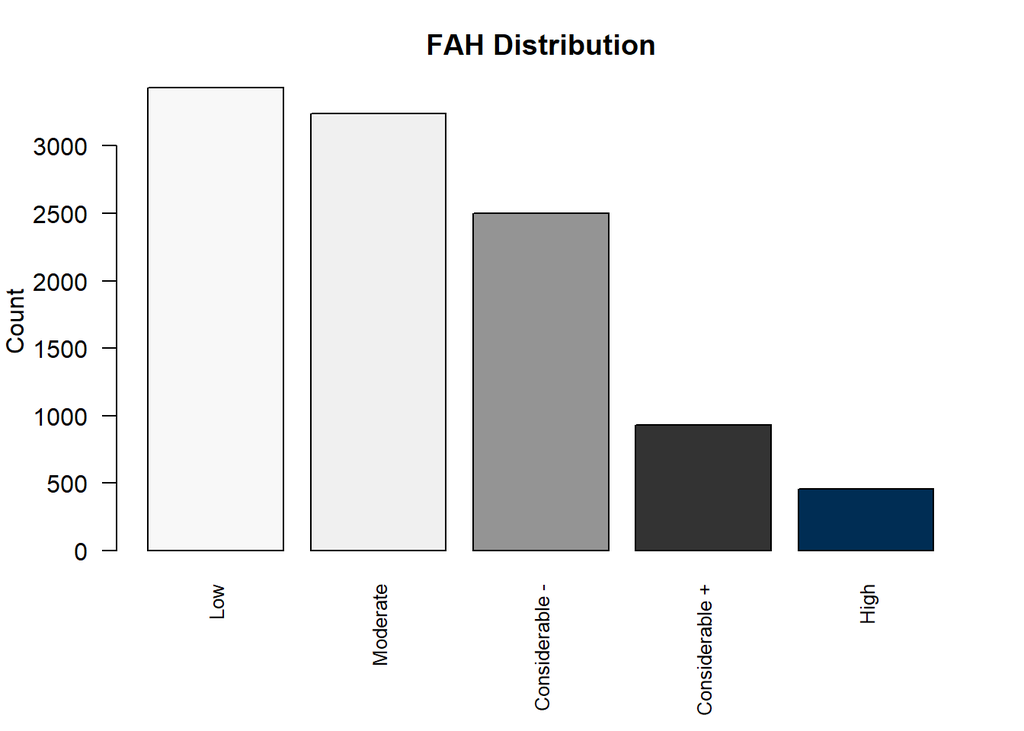

```r
# First plot - Bar chart (ordinal order, colors light to dark for increasing risk)
par(mar = c(6, 4, 3, 2))
barplot(fah_distribution,
        main = "FAH Distribution",
        ylab = "Count",
        col = sais_palette[c(10,9,7,5,1)],  # Light to dark: Low (very light grey) to High (dark blue)
        las = 2,
        cex.names = 0.8)
```

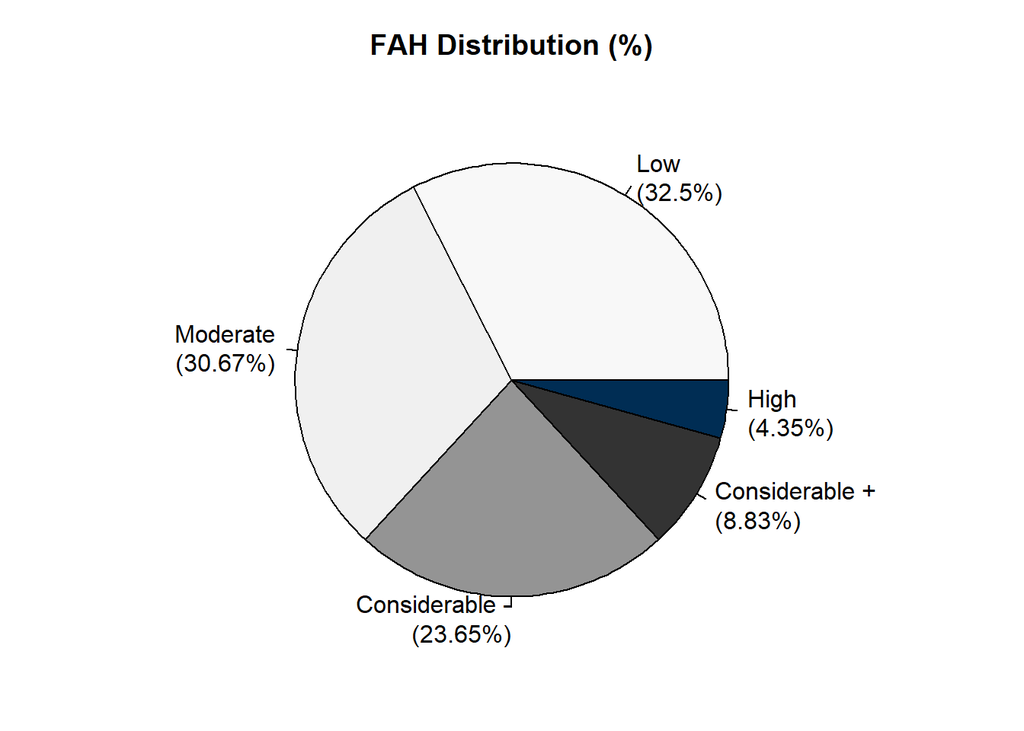

```r
# Second plot - Pie chart (gets full window space)
par(mar = c(2, 2, 3, 2))
pie(fah_distribution,
    main = "FAH Distribution (%)",
    col = sais_palette[c(10,9,7,5,1)],  # Same light-to-dark ordinal coloring
    labels = paste0(names(fah_distribution), "\n(", fah_pct, "%)"))
```

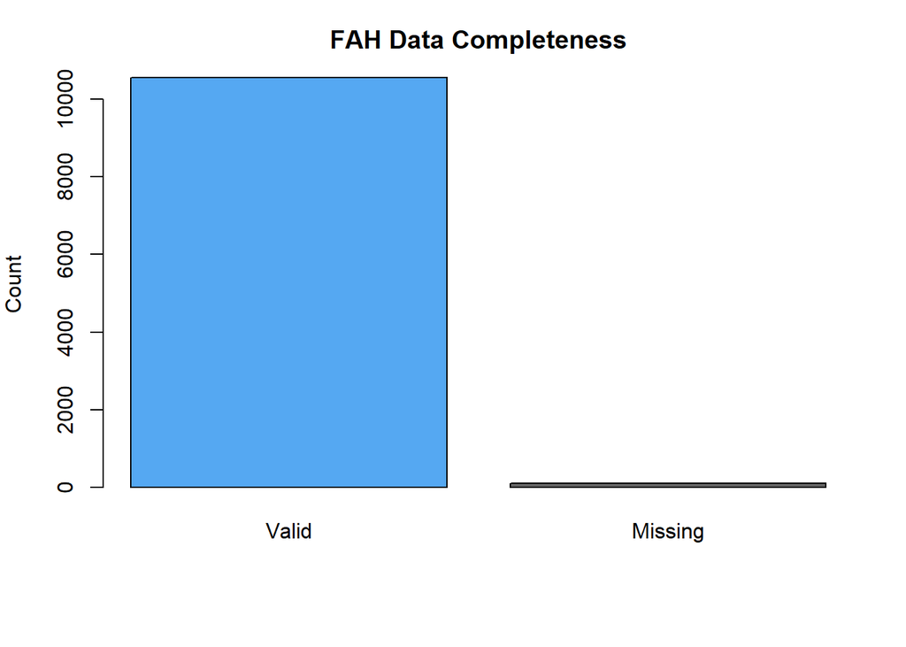

```r
# Third plot - Missing data
missing_data <- c(nrow(data) - fah_missing, fah_missing)
names(missing_data) <- c("Valid", "Missing")
par(mar = c(6, 4, 3, 2))
barplot(missing_data,
        main = "FAH Data Completeness",
        ylab = "Count",
        col = sais_palette[c(3,6)])  # Light blue for valid, mid grey for missing
```

```r
#
# MISSING DATA ANALYSIS

cat("\n=== MISSING DATA ANALYSIS ===\n")
```

```
=== MISSING DATA ANALYSIS ===
```

```r
# Variable-wise missing analysis (already computed in data_structure)
missing_summary <- data_structure %>%
  select(Variable, Missing, Missing_Pct, Variable_Type) %>%
  arrange(desc(Missing_Pct))

cat("Missing Data by Variable:\n")
```

```
Missing Data by Variable:
```

```r
kable(missing_summary, caption = "Missing Data Analysis by Variable") %>%
  kable_styling(bootstrap_options = c("striped", "hover", "condensed"))
```

Missing Data Analysis by Variable

|  | Variable | Missing | Missing_Pct | Variable_Type |
| --- | --- | --- | --- | --- |
| AV.Cat | AV.Cat | 2494 | 23.37 | Numeric |
| Ski.Pen | Ski.Pen | 2404 | 22.53 | Numeric |
| Summit.Wind.Dir | Summit.Wind.Dir | 1318 | 12.35 | Numeric |
| Crystals | Crystals | 988 | 9.26 | Numeric |
| Summit.Wind.Speed | Summit.Wind.Speed | 909 | 8.52 | Numeric |
| Summit.Air.Temp | Summit.Air.Temp | 754 | 7.07 | Numeric |
| Snow.Index | Snow.Index | 745 | 6.98 | Numeric |
| Max.Temp.Grad | Max.Temp.Grad | 710 | 6.65 | Numeric |
| Max.Hardness.Grad | Max.Hardness.Grad | 629 | 5.89 | Numeric |
| Precip.Code | Precip.Code | 583 | 5.46 | Categorical |
| Wetness | Wetness | 576 | 5.40 | Numeric |
| Insolation | Insolation | 507 | 4.75 | Numeric |
| OAH | OAH | 453 | 4.25 | Categorical |
| Snow.Temp | Snow.Temp | 410 | 3.84 | Numeric |
| Aspect | Aspect | 355 | 3.33 | Numeric |
| No.Settle | No.Settle | 289 | 2.71 | Numeric |
| Total.Snow.Depth | Total.Snow.Depth | 163 | 1.53 | Numeric |
| Wind.Dir | Wind.Dir | 158 | 1.48 | Numeric |
| FAH | FAH | 109 | 1.02 | Categorical |
| Wind.Speed | Wind.Speed | 53 | 0.50 | Numeric |
| Foot.Pen | Foot.Pen | 42 | 0.39 | Numeric |
| Incline | Incline | 36 | 0.34 | Numeric |
| Air.Temp | Air.Temp | 34 | 0.32 | Numeric |
| Cloud | Cloud | 29 | 0.27 | Numeric |
| Obs | Obs | 21 | 0.20 | Categorical |
| Location | Location | 9 | 0.08 | Categorical |
| Alt | Alt | 6 | 0.06 | Numeric |
| Date | Date | 0 | 0.00 | Categorical |
| Area | Area | 0 | 0.00 | Categorical |
| OSgrid | OSgrid | 0 | 0.00 | Categorical |
| longitude | longitude | 0 | 0.00 | Numeric |
| latitude | latitude | 0 | 0.00 | Numeric |
| Drift | Drift | 0 | 0.00 | Numeric |
| Rain.at.900 | Rain.at.900 | 0 | 0.00 | Numeric |

```r
# Threshold analysis
high_missing_vars <- missing_summary$Variable[missing_summary$Missing_Pct > 20]
moderate_missing_vars <- missing_summary$Variable[missing_summary$Missing_Pct > 5 & missing_summary$Missing_Pct <= 20]

cat(sprintf("\n=== MISSING DATA THRESHOLD ANALYSIS ===\n"))
```

```
=== MISSING DATA THRESHOLD ANALYSIS ===
```

```r
cat(sprintf("Variables with >20%% missing: %d\n", length(high_missing_vars)))
```

```
Variables with >20% missing: 2
```

```r
if(length(high_missing_vars) > 0) {
  cat("High missing variables:", paste(high_missing_vars, collapse = ", "), "\n")
}
```

```
High missing variables: AV.Cat, Ski.Pen
```

```r
cat(sprintf("Variables with 5-20%% missing: %d\n", length(moderate_missing_vars)))
```

```
Variables with 5-20% missing: 9
```

```r
if(length(moderate_missing_vars) > 0) {
  cat("Moderate missing variables:", paste(moderate_missing_vars, collapse = ", "), "\n")
}
```

```
Moderate missing variables: Summit.Wind.Dir, Crystals, Summit.Wind.Speed, Summit.Air.Temp, Snow.Index, Max.Temp.Grad, Max.Hardness.Grad, Precip.Code, Wetness
```

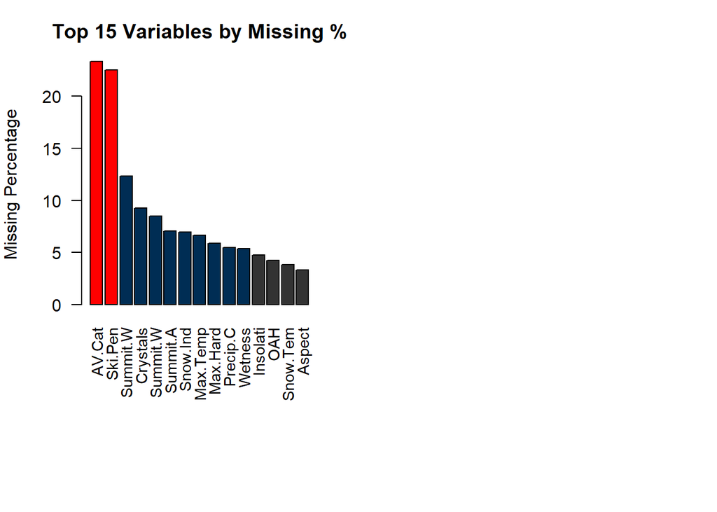

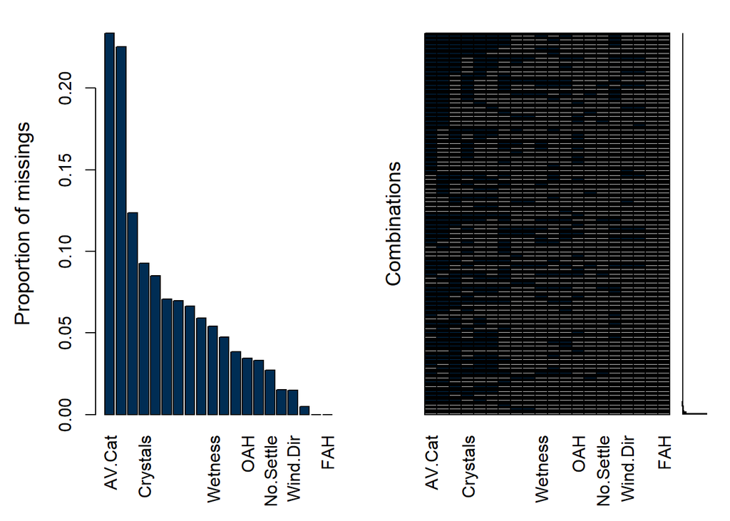

```
 Variables sorted by number of missings:
          Variable       Count
            AV.Cat 0.233717552
           Ski.Pen 0.225283479
   Summit.Wind.Dir 0.123512323
          Crystals 0.092587386
 Summit.Wind.Speed 0.085184144
   Summit.Air.Temp 0.070658795
        Snow.Index 0.069815387
     Max.Temp.Grad 0.066535470
 Max.Hardness.Grad 0.058944804
           Wetness 0.053978071
        Insolation 0.047511948
         Snow.Temp 0.038421891
               OAH 0.034579702
            Aspect 0.033267735
         No.Settle 0.027082748
  Total.Snow.Depth 0.015275045
          Wind.Dir 0.014806485
        Wind.Speed 0.004966732
       Precip.Code 0.000000000
               FAH 0.000000000
```

```r
# Missing data visualization
par(mfrow = c(1, 2), mar = c(10, 4, 3, 2))

# Top 15 variables by missing percentage
top_missing <- head(missing_summary, 15)
barplot(top_missing$Missing_Pct,
        names.arg = substr(top_missing$Variable, 1, 8),
        main = "Top 15 Variables by Missing %",
        ylab = "Missing Percentage",
        col = ifelse(top_missing$Missing_Pct > 20, "red",  # red for high missing
                    ifelse(top_missing$Missing_Pct > 5, sais_palette[1],  # Dark grey for moderate
                           sais_palette[5])),  # Light grey for low
        las = 2,
        cex.names = 0.9)

# Missing data heatmap (top 20 variables)
if(require(VIM, quietly = TRUE)) {
  top_20_vars <- head(missing_summary$Variable, 20)
  aggr(data[, top_20_vars],
       col = c(sais_palette[8], sais_palette[1]),  # Light grey for present, dark blue for missing
       numbers = TRUE,
       sortVars = TRUE)
}
```

```r
par(mfrow = c(1, 1))
```

This code chunk conducts geographical and temporal analyses to understand the spatial and time-based distribution of the avalanche forecast data. This section examines observation counts across different forecasting areas, creates summary tables showing area-specific statistics, and calculates geographic coverage using latitude and longitude coordinates for each region.

Bar plots and pie charts visualize the distribution of observations across areas to identify potential geographic biases or data concentration patterns. The temporal analysis converts date fields and examines the dataset’s time span, calculating yearly and monthly distributions to assess seasonal patterns typical in avalanche forecasting.

Time series visualizations including daily observation counts, annual trends, and monthly patterns help identify data collection consistency and seasonal variations. The analysis concludes with data consistency metrics including mean annual observations, standard deviation, and coefficient of variation to evaluate temporal data quality.

```r
# GEOGRAPHICAL ANALYSIS

cat("\n GEOGRAPHICAL ANALYSIS \n")
```

```
 GEOGRAPHICAL ANALYSIS
```

```
Observations by Forecasting Area:

Geographic Spread by Area:
```

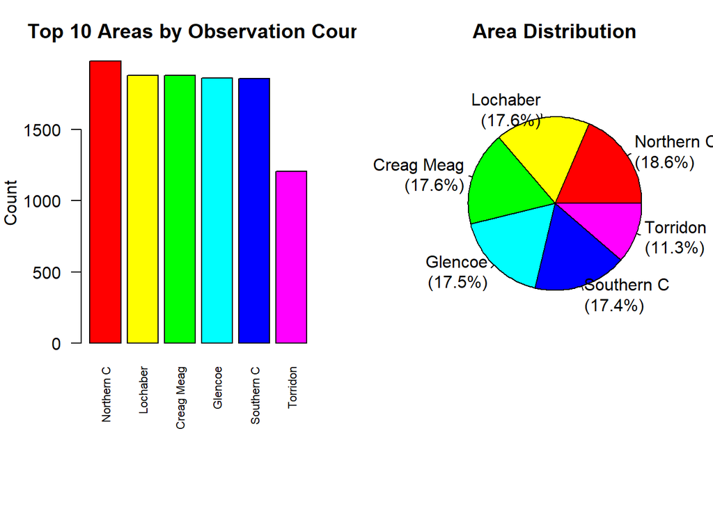

```r
if("Area" %in% colnames(data)) {
  # Area distribution
  area_distribution <- table(data$Area)
  area_summary <- data.frame(
    Area = names(area_distribution),
    Count = as.numeric(area_distribution),
    Percentage = round(as.numeric(prop.table(area_distribution) * 100), 2),
    stringsAsFactors = FALSE
  ) %>%
    arrange(desc(Count))

  cat("Observations by Forecasting Area:\n")
  kable(area_summary, caption = "Distribution of Observations by Area") %>%
    kable_styling(bootstrap_options = c("striped", "hover", "condensed"))

  # Geographic spread analysis
  if(all(c("latitude", "longitude") %in% colnames(data))) {
    geo_summary <- data %>%
      filter(!is.na(latitude) & !is.na(longitude) & !is.na(Area)) %>%
      group_by(Area) %>%
      summarise(
        Observations = n(),
        Min_Lat = round(min(latitude, na.rm = TRUE), 3),
        Max_Lat = round(max(latitude, na.rm = TRUE), 3),
        Mean_Lat = round(mean(latitude, na.rm = TRUE), 3),
        Min_Lon = round(min(longitude, na.rm = TRUE), 3),
        Max_Lon = round(max(longitude, na.rm = TRUE), 3),
        Mean_Lon = round(mean(longitude, na.rm = TRUE), 3),
        .groups = 'drop'
      ) %>%
      arrange(desc(Observations))

    cat("\nGeographic Spread by Area:\n")
    kable(geo_summary, caption = "Geographic Coverage by Forecasting Area") %>%
      kable_styling(bootstrap_options = c("striped", "hover", "condensed"))
  }

  # Area visualization
  par(mfrow = c(1, 2), mar = c(8, 4, 3, 2))

  # Top areas bar plot
  top_areas <- head(area_summary, 10)
  barplot(top_areas$Count,
          names.arg = substr(top_areas$Area, 1, 10),
          main = "Top 10 Areas by Observation Count",
          ylab = "Count",
          col = rainbow(nrow(top_areas)),
          las = 2,
          cex.names = 0.7)

  # Area distribution pie chart (top 8 + others)
  if(nrow(area_summary) > 8) {
    top_8_areas <- head(area_summary, 8)
    other_count <- sum(tail(area_summary$Count, -8))
    pie_data <- c(top_8_areas$Count, other_count)
    pie_labels <- c(top_8_areas$Area, "Others")
  } else {
    pie_data <- area_summary$Count
    pie_labels <- area_summary$Area
  }

  pie(pie_data,
      labels = paste0(substr(pie_labels, 1, 10), "\n(",
                     round(pie_data/sum(pie_data)*100, 1), "%)"),
      main = "Area Distribution",
      col = rainbow(length(pie_data)))

  par(mfrow = c(1, 1))
}
```

```r
# TEMPORAL ANALYSIS

cat("\n=== TEMPORAL ANALYSIS ===\n")
```

```
=== TEMPORAL ANALYSIS ===
```

```
Data Collection Time Span:
- Start date: 2009-12-17
- End date: 2025-03-17
- Total period: 15.2 years (5569 days)

Observations by Year:

Observations by Month:
```

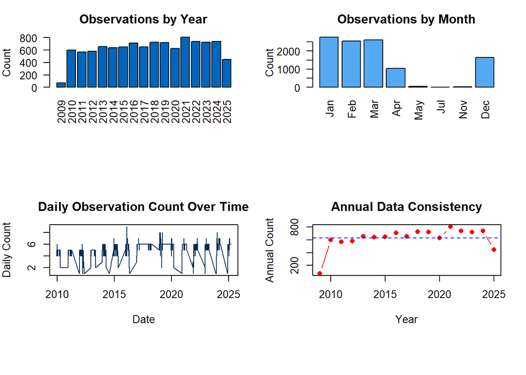

```
Data Consistency Metrics:
- Mean annual observations: 627.7
- Standard deviation: 165.9
- Coefficient of variation: 0.264
```

```r
if("Date" %in% colnames(data)) {
  # Convert date and handle missing values
  data_with_dates <- data %>%
    filter(!is.na(Date) & Date != "" & Date != "NA") %>%
    mutate(Date = as.Date(Date))

  if(nrow(data_with_dates) > 0) {
    # Time span analysis
    date_range <- range(data_with_dates$Date, na.rm = TRUE)
    total_days <- as.numeric(date_range[2] - date_range[1])
    total_years <- round(total_days / 365.25, 1)

    cat(sprintf("Data Collection Time Span:\n"))
    cat(sprintf("- Start date: %s\n", date_range[1]))
    cat(sprintf("- End date: %s\n", date_range[2]))
    cat(sprintf("- Total period: %.1f years (%d days)\n", total_years, total_days))

    # Yearly distribution
    data_with_dates$Year <- year(data_with_dates$Date)
    yearly_counts <- table(data_with_dates$Year)

    yearly_summary <- data.frame(
      Year = as.numeric(names(yearly_counts)),
      Count = as.numeric(yearly_counts),
      Percentage = round(as.numeric(prop.table(yearly_counts) * 100), 2),
      stringsAsFactors = FALSE
    )

    cat("\nObservations by Year:\n")
    kable(yearly_summary, caption = "Annual Distribution of Observations") %>%
      kable_styling(bootstrap_options = c("striped", "hover", "condensed"))

    # Monthly distribution
    data_with_dates$Month <- month(data_with_dates$Date)
    monthly_counts <- table(data_with_dates$Month)
    month_names <- month.name[as.numeric(names(monthly_counts))]

    monthly_summary <- data.frame(
      Month = month_names,
      Count = as.numeric(monthly_counts),
      Percentage = round(as.numeric(prop.table(monthly_counts) * 100), 2),
      stringsAsFactors = FALSE
    )

    cat("\nObservations by Month:\n")
    kable(monthly_summary, caption = "Monthly Distribution of Observations") %>%
      kable_styling(bootstrap_options = c("striped", "hover", "condensed"))

    # Temporal visualizations
    par(mfrow = c(2, 2), mar = c(8, 4, 3, 2))

    # Yearly distribution
    barplot(yearly_counts,
            main = "Observations by Year",
            ylab = "Count",
            col = sais_palette[2],  # Mid blue for yearly bars
            las = 2)

    # Monthly distribution
    barplot(monthly_counts,
            names.arg = substr(month_names, 1, 3),
            main = "Observations by Month",
            ylab = "Count",
            col = sais_palette[3],  # Light blue for monthly bars
            las = 2)

    # Time series plot
    daily_counts <- data_with_dates %>%
      count(Date) %>%
      arrange(Date)

    plot(daily_counts$Date, daily_counts$n,
         type = "l",
         main = "Daily Observation Count Over Time",
         xlab = "Date",
         ylab = "Daily Count",
         col = sais_palette[1])  # Dark blue for time series line

   # Data consistency check
  consistency_stats <- yearly_summary %>%
  summarise(
    Mean_Annual = round(mean(Count), 1),
    SD_Annual = round(sd(Count), 1),
    CV_Annual = round(sd(Count)/mean(Count), 3)
     )

  plot(yearly_summary$Year, yearly_summary$Count,
     type = "b",
     main = "Annual Data Consistency",
     xlab = "Year",
     ylab = "Annual Count",
     col = "red",
     pch = 16)
  abline(h = consistency_stats$Mean_Annual, col = "blue", lty = 2)


    cat(sprintf("\nData Consistency Metrics:\n"))
    cat(sprintf("- Mean annual observations: %.1f\n", consistency_stats$Mean_Annual))
    cat(sprintf("- Standard deviation: %.1f\n", consistency_stats$SD_Annual))
    cat(sprintf("- Coefficient of variation: %.3f\n", consistency_stats$CV_Annual))

    par(mfrow = c(1, 1))
  }
}
```

This code chunk assesses data quality through duplicate detection and forecast accuracy analysis. It identifies duplicate rows in the dataset and calculates their percentage. The chunk then performs a comprehensive comparison between forecast avalanche hazard (FAH) and observed avalanche hazard (OAH). A confusion matrix displays the relationship between predicted and actual hazard levels, while accuracy metrics are calculated for each risk level to identify patterns in forecasting performance. Visualizations include bar charts showing accuracy by hazard level and overall forecast performance.

```r
# DATA QUALITY ASSESSMENT

cat("\n=== DATA QUALITY ASSESSMENT ===\n")
```

```
=== DATA QUALITY ASSESSMENT ===
```

```r
# Duplicate detection
duplicate_rows <- sum(duplicated(data))
cat(sprintf("Duplicate Observations: %d (%.2f%%)\n", duplicate_rows, duplicate_rows/nrow(data)*100))
```

```
Duplicate Observations: 4 (0.04%)
```

```
Forecast vs Observed Comparison:
- Paired observations: 10181
- Forecast accuracy: 72.91%

Forecast vs Observed Confusion Matrix:
                Observed
Forecast         Considerable - Considerable + High  Low Moderate
  Considerable -           1553            173   20   48      627
  Considerable +            438            309   30   10      121
  High                      132             83  207    3       23
  Low                         2              1    0 3173       92
  Moderate                  160             15    1  779     2181

Forecast Accuracy by Risk Level:
```

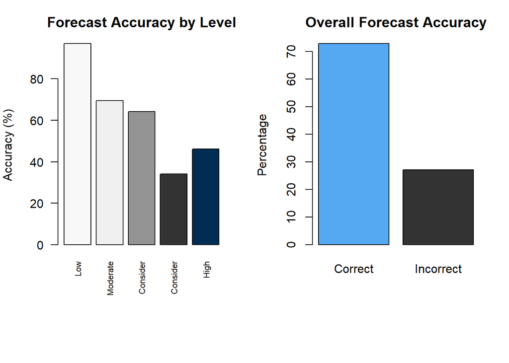

```r
# OAH vs FAH comparison (forecast vs observed avalanche hazard)
if(all(c("OAH", "FAH") %in% colnames(data))) {
  # Clean both variables
  comparison_data <- data %>%
    filter(!is.na(FAH) & FAH != "" & FAH != "NA" &
           !is.na(OAH) & OAH != "" & OAH != "NA") %>%
    mutate(
      FAH_clean = str_trim(str_to_title(FAH)),
      OAH_clean = str_trim(str_to_title(OAH))
    )

  if(nrow(comparison_data) > 0) {
    # Accuracy calculation
    forecast_accuracy <- mean(comparison_data$FAH_clean == comparison_data$OAH_clean, na.rm = TRUE)

    cat(sprintf("\nForecast vs Observed Comparison:\n"))
    cat(sprintf("- Paired observations: %d\n", nrow(comparison_data)))
    cat(sprintf("- Forecast accuracy: %.2f%%\n", forecast_accuracy * 100))

    # Confusion matrix for forecast vs observed
    confusion_fah_oah <- table(Forecast = comparison_data$FAH_clean,
                               Observed = comparison_data$OAH_clean)

    cat("\nForecast vs Observed Confusion Matrix:\n")
    print(confusion_fah_oah)

    # Accuracy by risk level
    accuracy_by_level <- comparison_data %>%
      group_by(FAH_clean) %>%
      summarise(
        Count = n(),
        Correct = sum(FAH_clean == OAH_clean),
        Accuracy = round(mean(FAH_clean == OAH_clean) * 100, 2),
        .groups = 'drop'
      ) %>%
      arrange(desc(Count))

    cat("\nForecast Accuracy by Risk Level:\n")
    kable(accuracy_by_level, caption = "Forecast Accuracy by FAH Level") %>%
      kable_styling(bootstrap_options = c("striped", "hover", "condensed"))

    # Visualization
    par(mfrow = c(1, 2), mar = c(8, 4, 3, 2))

    # Accuracy by level
    barplot(accuracy_by_level$Accuracy,
            names.arg = substr(accuracy_by_level$FAH_clean, 1, 8),
            main = "Forecast Accuracy by Level",
            ylab = "Accuracy (%)",
            col = sais_palette[c(10,9,7,5,1)],  # Use first 5 colors for variety
            las = 2,
            cex.names = 0.7)

    # Overall accuracy visualization
    accuracy_data <- c(forecast_accuracy * 100, (1 - forecast_accuracy) * 100)
    names(accuracy_data) <- c("Correct", "Incorrect")
    barplot(accuracy_data,
            main = "Overall Forecast Accuracy",
            ylab = "Percentage",
            col = sais_palette[c(3,5)])  # Light blue for Correct, dark grey for Incorrect

    par(mfrow = c(1, 1))
  }
}
```

This code chunk analyzes relationships between numeric variables through correlation analysis to identify potential multicollinearity issues. The analysis computes pairwise correlations using complete observations, identifies highly correlated variable pairs with absolute correlation coefficients above 0.7, and flags potential multicollinearity problems where correlations exceed 0.9. Summary tables display the most correlated variable pairs ranked by correlation strength. A correlation matrix heatmap visualizes the relationships between variables (limited to the top 20 most important variables for readability).

```r
# FEATURE RELATIONSHIP ANALYSIS

cat("\n=== FEATURE RELATIONSHIP ANALYSIS ===\n")
```

```
=== FEATURE RELATIONSHIP ANALYSIS ===
```

```
Highly Correlated Variable Pairs (|r| > 0.7):
```

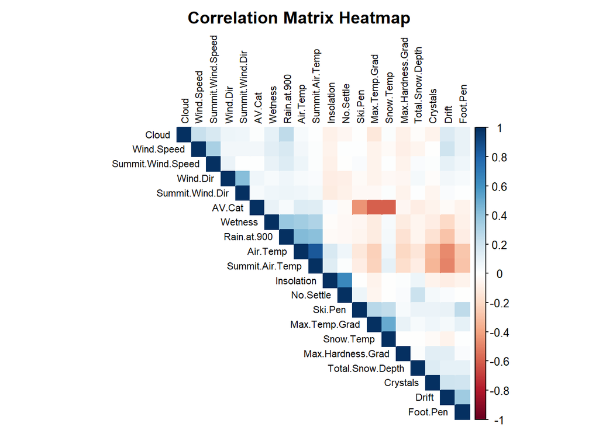

```r
# Correlation analysis for numeric variables
if(length(numeric_vars) > 1) {
  # Prepare numeric data for correlation
  numeric_data_clean <- data[, numeric_vars, drop = FALSE]
  for(col in names(numeric_data_clean)) {
    numeric_data_clean[[col]] <- as.numeric(ifelse(numeric_data_clean[[col]] == "NA", NA, numeric_data_clean[[col]]))
  }

  # Calculate correlation matrix
  cor_matrix <- cor(numeric_data_clean, use = "pairwise.complete.obs")

  # Find highly correlated pairs (>0.7 or <-0.7)
  high_cor_pairs <- which(abs(cor_matrix) > 0.7 & cor_matrix != 1, arr.ind = TRUE)

  if(nrow(high_cor_pairs) > 0) {
    high_cor_df <- data.frame(
      Variable1 = rownames(cor_matrix)[high_cor_pairs[,1]],
      Variable2 = colnames(cor_matrix)[high_cor_pairs[,2]],
      Correlation = round(cor_matrix[high_cor_pairs], 3),
      stringsAsFactors = FALSE
    )

    # Remove duplicate pairs
    high_cor_df <- high_cor_df[high_cor_df$Variable1 < high_cor_df$Variable2, ]
    high_cor_df <- high_cor_df[order(abs(high_cor_df$Correlation), decreasing = TRUE), ]

    cat("Highly Correlated Variable Pairs (|r| > 0.7):\n")
    kable(high_cor_df, caption = "Highly Correlated Variable Pairs") %>%
      kable_styling(bootstrap_options = c("striped", "hover", "condensed"))

    # Multicollinearity assessment
    very_high_cor <- high_cor_df[abs(high_cor_df$Correlation) > 0.9, ]
    if(nrow(very_high_cor) > 0) {
      cat("\nPotential Multicollinearity Issues (|r| > 0.9):\n")
      kable(very_high_cor, caption = "Variables with Potential Multicollinearity") %>%
        kable_styling(bootstrap_options = c("striped", "hover", "condensed"))
    }
  } else {
    cat("No highly correlated variable pairs found (|r| > 0.7)\n")
  }

  # Correlation visualization
  if(corrplot_available) {
    # Select top variables for visualization (max 20 for readability)
    if(ncol(cor_matrix) > 20) {
      # Select variables with highest variance or most correlations
      var_importance <- rowSums(abs(cor_matrix), na.rm = TRUE)
      top_vars <- names(sort(var_importance, decreasing = TRUE)[1:20])
      cor_matrix_subset <- cor_matrix[top_vars, top_vars]
    } else {
      cor_matrix_subset <- cor_matrix
    }

    corrplot(cor_matrix_subset,
             method = "color",
             type = "upper",
             order = "hclust",
             tl.cex = 0.7,
             tl.col = "black",
             title = "Correlation Matrix Heatmap",
             mar = c(0, 0, 2, 0))
  }
}
```

This code chunk performs outlier detection across all numeric variables using the Interquartile Range (IQR) method to identify extreme values. The chunk calculates quartiles, IQR bounds, and outlier thresholds (Q1-1.5×IQR and Q3+1.5×IQR) for each variable, then counts observations falling outside these bounds. A comprehensive summary table displays outlier statistics including counts and percentages, sorted by outlier prevalence to prioritize variables requiring attention. The chunk identifies variables with high outlier rates (>5%) that may need preprocessing such as transformation, capping, or removal before model training. Box plots visualize the top six variables with the highest outlier percentages, highlighting extreme values in red to provide intuitive understanding of data distribution issues that could impact neural network performance and convergence.

```r
# OUTLIER ANALYSIS

cat("\n=== OUTLIER ANALYSIS ===\n")
```

```
=== OUTLIER ANALYSIS ===
```

```r
# Outlier detection for numeric variables using IQR method
outlier_summary <- data.frame(
  Variable = character(),
  Total_Obs = numeric(),
  Valid_Obs = numeric(),
  Q1 = numeric(),
  Q3 = numeric(),
  IQR = numeric(),
  Lower_Bound = numeric(),
  Upper_Bound = numeric(),
  Outliers = numeric(),
  Outlier_Pct = numeric(),
  stringsAsFactors = FALSE
)

numeric_data_for_outliers <- data[, numeric_vars, drop = FALSE]
for(col in names(numeric_data_for_outliers)) {
  numeric_data_for_outliers[[col]] <- as.numeric(ifelse(numeric_data_for_outliers[[col]] == "NA", NA, numeric_data_for_outliers[[col]]))
}

for(var in numeric_vars) {
  if(var %in% colnames(numeric_data_for_outliers)) {
    values <- numeric_data_for_outliers[[var]]
    valid_values <- values[!is.na(values)]

    if(length(valid_values) > 0) {
      Q1 <- quantile(valid_values, 0.25)
      Q3 <- quantile(valid_values, 0.75)
      IQR_val <- Q3 - Q1
      lower_bound <- Q1 - 1.5 * IQR_val
      upper_bound <- Q3 + 1.5 * IQR_val

      outliers <- sum(valid_values < lower_bound | valid_values > upper_bound)
      outlier_pct <- round(outliers / length(valid_values) * 100, 2)

      outlier_summary <- rbind(outlier_summary, data.frame(
        Variable = var,
        Total_Obs = length(values),
        Valid_Obs = length(valid_values),
        Q1 = round(Q1, 3),
        Q3 = round(Q3, 3),
        IQR = round(IQR_val, 3),
        Lower_Bound = round(lower_bound, 3),
        Upper_Bound = round(upper_bound, 3),
        Outliers = outliers,
        Outlier_Pct = outlier_pct,
        stringsAsFactors = FALSE
      ))
    }
  }
}

# Sort by outlier percentage
outlier_summary <- outlier_summary[order(outlier_summary$Outlier_Pct, decreasing = TRUE), ]

cat("Outlier Analysis Summary:\n")
```

```
Outlier Analysis Summary:
```

```r
kable(outlier_summary, caption = "Outlier Detection Results (IQR Method)") %>%
  kable_styling(bootstrap_options = c("striped", "hover", "condensed"))
```

Outlier Detection Results (IQR Method)

|  | Variable | Total_Obs | Valid_Obs | Q1 | Q3 | IQR | Lower_Bound | Upper_Bound | Outliers | Outlier_Pct |
| --- | --- | --- | --- | --- | --- | --- | --- | --- | --- | --- |
| 25%22 | Crystals | 10671 | 9683 | 0.000 | 0.000 | 0.000 | 0.000 | 0.000 | 2165 | 22.36 |
| 25%20 | Snow.Index | 10671 | 9926 | 0.000 | 0.000 | 0.000 | 0.000 | 0.000 | 2156 | 21.72 |
| 25%13 | Rain.at.900 | 10671 | 10671 | 0.000 | 0.000 | 0.000 | 0.000 | 0.000 | 2040 | 19.12 |
| 25%24 | AV.Cat | 10671 | 8177 | 0.000 | 0.000 | 0.000 | 0.000 | 0.000 | 1541 | 18.85 |
| 25%8 | Cloud | 10671 | 10642 | 70.000 | 100.000 | 30.000 | 25.000 | 145.000 | 1233 | 11.59 |
| 25%1 | latitude | 10671 | 10671 | 56.817 | 57.111 | 0.295 | 56.374 | 57.554 | 1054 | 9.88 |
| 25%12 | Ski.Pen | 10671 | 8267 | 0.000 | 0.000 | 0.000 | 0.000 | 0.000 | 702 | 8.49 |
| 25%10 | Total.Snow.Depth | 10671 | 10508 | 45.000 | 118.000 | 73.000 | -64.500 | 227.500 | 834 | 7.94 |
| 25%17 | Max.Temp.Grad | 10671 | 9961 | 0.000 | 1.000 | 1.000 | -1.500 | 2.500 | 722 | 7.25 |
| 25%25 | Snow.Temp | 10671 | 10261 | -2.200 | 0.000 | 2.200 | -5.500 | 3.300 | 605 | 5.90 |
| 25%15 | Summit.Wind.Dir | 10671 | 9353 | 160.000 | 250.000 | 90.000 | 25.000 | 385.000 | 517 | 5.53 |
| 25%4 | Incline | 10671 | 10635 | 22.000 | 32.000 | 10.000 | 7.000 | 47.000 | 571 | 5.37 |
| 25%11 | Foot.Pen | 10671 | 10629 | 5.000 | 20.000 | 15.000 | -17.500 | 42.500 | 287 | 2.70 |
| 25%23 | Wetness | 10671 | 10095 | 1.000 | 2.000 | 1.000 | -0.500 | 3.500 | 226 | 2.24 |
| 25%7 | Wind.Speed | 10671 | 10618 | 8.000 | 22.000 | 14.000 | -13.000 | 43.000 | 214 | 2.02 |
| 25%2 | Alt | 10671 | 10665 | 800.000 | 1030.000 | 230.000 | 455.000 | 1375.000 | 167 | 1.57 |
| 25%5 | Air.Temp | 10671 | 10637 | -2.100 | 2.100 | 4.200 | -8.400 | 8.400 | 154 | 1.45 |
| 25%16 | Summit.Wind.Speed | 10671 | 9762 | 14.000 | 38.000 | 24.000 | -22.000 | 74.000 | 117 | 1.20 |
| 25%14 | Summit.Air.Temp | 10671 | 9917 | -3.600 | 0.800 | 4.400 | -10.200 | 7.400 | 115 | 1.16 |
| 25%19 | No.Settle | 10671 | 10382 | 54.000 | 206.000 | 152.000 | -174.000 | 434.000 | 71 | 0.68 |
| 25%3 | Aspect | 10671 | 10316 | 50.000 | 225.000 | 175.000 | -212.500 | 487.500 | 7 | 0.07 |
| 25%21 | Insolation | 10671 | 10164 | 3.000 | 10.000 | 7.000 | -7.500 | 20.500 | 4 | 0.04 |
| 25%6 | Wind.Dir | 10671 | 10513 | 150.000 | 270.000 | 120.000 | -30.000 | 450.000 | 1 | 0.01 |
| 25% | longitude | 10671 | 10671 | -4.963 | -3.652 | 1.311 | -6.929 | -1.686 | 0 | 0.00 |
| 25%9 | Drift | 10671 | 10671 | 0.000 | 1.000 | 1.000 | -1.500 | 2.500 | 0 | 0.00 |
| 25%18 | Max.Hardness.Grad | 10671 | 10042 | 1.000 | 3.000 | 2.000 | -2.000 | 6.000 | 0 | 0.00 |

```r
# Identify variables with high outlier rates
high_outlier_vars <- outlier_summary$Variable[outlier_summary$Outlier_Pct > 5]
cat(sprintf("\nVariables with >5%% outliers: %d\n", length(high_outlier_vars)))
```

```
Variables with >5% outliers: 12
```

```r
if(length(high_outlier_vars) > 0) {
  cat("High outlier variables:", paste(high_outlier_vars, collapse = ", "), "\n")
}
```

```
High outlier variables: Crystals, Snow.Index, Rain.at.900, AV.Cat, Cloud, latitude, Ski.Pen, Total.Snow.Depth, Max.Temp.Grad, Snow.Temp, Summit.Wind.Dir, Incline
```

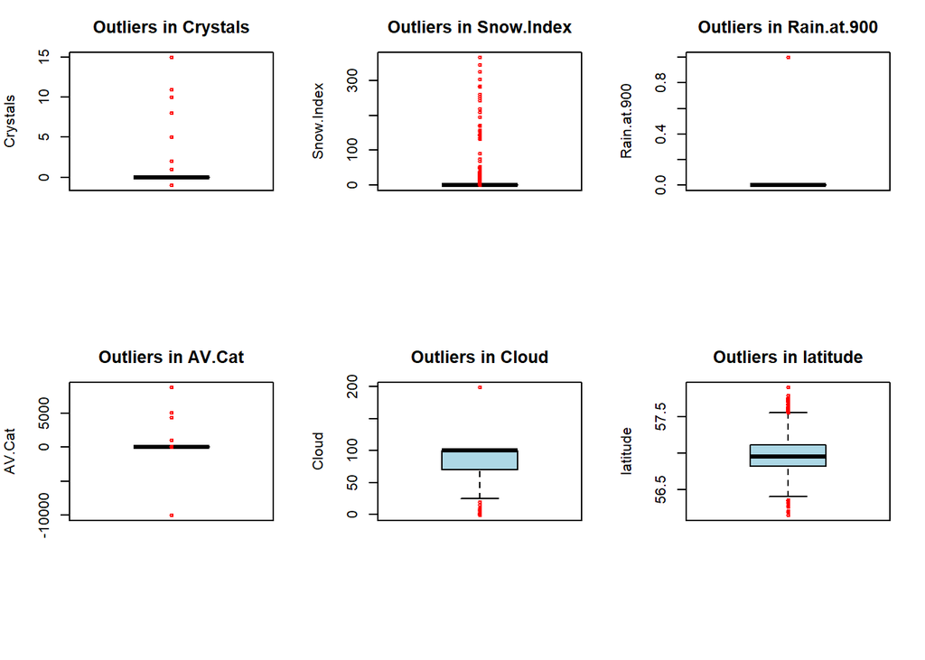

```r
# Outlier visualization - box plots for top outlier variables
if(nrow(outlier_summary) > 0) {
  top_outlier_vars <- head(outlier_summary$Variable, 6)

  par(mfrow = c(2, 3), mar = c(8, 4, 3, 2))

  for(var in top_outlier_vars) {
    if(var %in% colnames(numeric_data_for_outliers)) {
      values <- numeric_data_for_outliers[[var]]
      boxplot(values,
              main = paste("Outliers in", var),
              ylab = var,
              col = "lightblue",
              outcol = "red",
              outcex = 0.5)
    }
  }

  par(mfrow = c(1, 1))
}
```

The coding chunk below provides a basic summary of the EDA findings.

```r
# EDA SUMMARY
cat("\n=== KEY FINDINGS SUMMARY ===\n")
```

```
=== KEY FINDINGS SUMMARY ===
```

```r
cat(sprintf("- Total observations: %d\n", nrow(data)))
```

```
- Total observations: 10671
```

```r
cat(sprintf("- Variables: %d (%d numeric, %d categorical)\n",
            ncol(data), length(numeric_vars), length(categorical_vars)))
```

```
- Variables: 34 (26 numeric, 8 categorical)
```

```r
cat(sprintf("- Missing FAH: %.1f%%\n", fah_missing_pct))
```

```
- Missing FAH: 1.0%
```

```r
cat(sprintf("- Duplicate rows: %d\n", duplicate_rows))
```

```
- Duplicate rows: 4
```

```r
if(exists("forecast_accuracy")) {
  cat(sprintf("- Forecast accuracy: %.1f%%\n", forecast_accuracy * 100))
}
```

```
- Forecast accuracy: 72.9%
```

```r
if(exists("high_cor_pairs") && nrow(high_cor_pairs) > 0) {
  cat(sprintf("- High correlations: %d pairs\n", nrow(high_cor_df)))
}
```

```
- High correlations: 1 pairs
```

```r
if(nrow(outlier_summary) > 0) {
  cat(sprintf("- Variables with >5%% outliers: %d\n", length(high_outlier_vars)))
}
```

```
- Variables with >5% outliers: 12
```

```r
# Clean up large objects to save memory
rm(list = c("numeric_data", "numeric_data_clean", "numeric_data_for_outliers",
            "comparison_data", "data_with_dates"))
if(exists("cor_matrix")) rm(cor_matrix)
if(exists("cor_matrix_subset")) rm(cor_matrix_subset)

gc()  # Garbage collection
```

```
          used  (Mb) gc trigger  (Mb) max used  (Mb)
Ncells 2862010 152.9    5153475 275.3  5153475 275.3
Vcells 5299192  40.5   10146329  77.5 10144272  77.4
```

This section of the Model now starts with data preprocessing. For good measure, the data set is reloaded.

This chunk handles the initial data preprocessing steps for the dataset. This chunk begin by loading the raw data and removing the OAH (observed avalanche hazard) and Obs (observer) columns since our objective is to predict the forecasted avalanche hazard (FAH) rather than the observed outcomes. The chunk then filters out observations with missing or invalid FAH values, as these represent our target variable. To ensure consistency in the categorical target variable, we standardize the FAH values by trimming whitespace, normalizing case formatting, and mapping various text representations to five standard avalanche hazard levels: Low, Moderate, Considerable -, Considerable +, and High. Finally, we assess missing data patterns across all remaining variables and remove columns with more than 20% missing values to maintain data quality for our neural network model. This preprocessing ensures we have a clean dataset with a properly formatted target variable and reduces potential issues from excessive missing data in predictor variables.

```r
# DATA PREPROCESSING
data <- read.csv("scotland_avalanche_forecasts_2009_2025.csv", stringsAsFactors = FALSE)

cat("\n=== DATA PREPROCESSING ===\n")
```

```
=== DATA PREPROCESSING ===
```

```r
# Drop OAH (actual observations) and Obs (observer) columns
columns_to_drop <- c("OAH", "Obs")
data <- data %>% select(-all_of(columns_to_drop))

# Remove observations with missing FAH
data_clean <- data %>%
  filter(!is.na(FAH) & FAH != "" & FAH != "NA")

cat("Observations after removing missing FAH:", nrow(data_clean), "\n")
```

```
Observations after removing missing FAH: 10562
```

```r
# Properly examine and clean FAH values
cat("\nUnique FAH values found:\n")
```

```
Unique FAH values found:
```

```r
unique_fah <- unique(data_clean$FAH)
print(unique_fah)
```

```
[1] "Moderate"       "Considerable -" "Considerable +" "High"
[5] "Low"
```

```r
# Clean FAH values - handle case sensitivity and variations
data_clean$FAH <- str_trim(data_clean$FAH)  # Remove whitespace
data_clean$FAH <- str_to_title(data_clean$FAH)  # Standardize case

# Map variations to standard levels
data_clean$FAH <- case_when(
  str_detect(tolower(data_clean$FAH), "^low") ~ "Low",
  str_detect(tolower(data_clean$FAH), "^moderate") ~ "Moderate",
  str_detect(tolower(data_clean$FAH), "considerable.*-|considerable.*minus") ~ "Considerable -",
  str_detect(tolower(data_clean$FAH), "considerable.*\\+|considerable.*plus") ~ "Considerable +",
  str_detect(tolower(data_clean$FAH), "^high") ~ "High",
  TRUE ~ data_clean$FAH
)

# Check cleaned FAH distribution
cat("\nCleaned FAH distribution:\n")
```

```
Cleaned FAH distribution:
```

```r
print(table(data_clean$FAH, useNA = "always"))
```

```
Considerable - Considerable +           High            Low       Moderate
          2498            933            459           3433           3239
          <NA>
             0
```

```r
# Remove any remaining unmapped values
valid_fah_levels <- c("Low", "Moderate", "Considerable -", "Considerable +", "High")
data_clean <- data_clean %>%
  filter(FAH %in% valid_fah_levels)

cat("Final observations with valid FAH:", nrow(data_clean), "\n")
```

```
Final observations with valid FAH: 10562
```

```r
cat("Final FAH distribution:\n")
```

```
Final FAH distribution:
```

```r
print(table(data_clean$FAH))
```

```
Considerable - Considerable +           High            Low       Moderate
          2498            933            459           3433           3239
```

```r
# Check missing value percentages for all columns
missing_percentages <- data_clean %>%
  summarise_all(~sum(is.na(.) | . == "" | . == "NA") / length(.) * 100) %>%
  gather(key = "Variable", value = "Missing_Percentage") %>%
  arrange(desc(Missing_Percentage))

print(missing_percentages)
```

```
            Variable Missing_Percentage
1             AV.Cat        23.36678659
2            Ski.Pen        22.48627154
3    Summit.Wind.Dir        12.35561447
4           Crystals         9.20280250
5  Summit.Wind.Speed         8.53058133
6    Summit.Air.Temp         7.06305624
7         Snow.Index         6.97784511
8      Max.Temp.Grad         6.07839424
9  Max.Hardness.Grad         5.32096194
10           Wetness         5.25468661
11       Precip.Code         5.15053967
12        Insolation         4.74341981
13         Snow.Temp         3.66407877
14            Aspect         2.94451808
```

[output cut: 18 more lines]

```r
# Drop columns with >20% missing values
high_missing_threshold <- 20
high_missing_cols <- missing_percentages %>%
  filter(Missing_Percentage > high_missing_threshold) %>%
  pull(Variable)

if(length(high_missing_cols) > 0) {
  data_clean <- data_clean %>% select(-all_of(high_missing_cols))
  cat("Dropped high-missing columns:", paste(high_missing_cols, collapse = ", "), "\n")
}
```

```
Dropped high-missing columns: AV.Cat, Ski.Pen
```

```r
# OUTLIER DETECTION AND REMOVAL

#Altitude (Alt) - removed via IQR method

#Problem: Two observations have impossible values (244,859m and 77,044m)
#Context: Scotland's highest peak (Ben Nevis) is 1,345m
#Action: Remove these observations

#Aspect - Not removed via iqr - removed specifically

#Problem: Values exceeding 163,770 degrees (impossible for compass directions)
#Context: Aspect should be 0-360 degrees
#Action: Remove observations with Aspect > 360

#Wind Speed - removed via iqr method

#Current range: -2 to 290 km/h
#Outlier cap:  remove negative values and cap at 250
#Rationale: Winds >200 km/h are hurricane-force and extremely rare in Scottish mountains

#Summit Wind Speed - removed via iqr method

#Current range: -8 to 360 km/h
#Outlier threshold: remove negative values and cap at 300
#Rationale: Summit winds can be stronger but >300 km/h values are likely errors

#Total Snow Depth - removed via iqr method

#Current range: -1 to 3,000cm (30 meters!)
#Outlier cap: > remove negative values and cap at 1200cm
#Rationale: Snow depths >10m are extremely rare and likely measurement errors

#Cloud Cover - not removed via iqr method - special removal

#Current range: -1 to 199%
#Issue: Values >100% and negative values
#Outlier cap: 0% to 100% (remove impossible values)

#Foot Penetration & Ski Penetration - removed via iqr

#Foot Pen range: -1 to 300cm
#Ski Pen range: -1 to 55cm
#Action: Cap negative values at 0

#Incline - not removed via iqr method - special removal

#Range: -1 to 1,020 degrees
#Issue: Slopes >90° are overhangs (possible but rare)
#Recommended cap: remove negative values and values over 180

cat("\n=== OUTLIER Removal ===\n")
```

```
=== OUTLIER Removal ===
```

```r
# Convert character "NA" to actual NA for numeric columns
numeric_cols <- c("Alt", "Aspect", "Wind.Speed", "Summit.Wind.Speed",
                  "Total.Snow.Depth", "Cloud", "Foot.Pen", "Incline",
                  "Air.Temp", "Summit.Air.Temp", "Max.Temp.Grad",
                  "Max.Hardness.Grad", "No.Settle", "Snow.Index",
                  "Insolation", "Crystals", "Wetness", "Snow.Temp")

for(col in numeric_cols) {
  if(col %in% colnames(data_clean)) {
    data_clean[[col]] <- as.numeric(ifelse(data_clean[[col]] == "NA", NA, data_clean[[col]]))
  }
}

# robust outlier detection using IQR method
remove_outliers_iqr <- function(data, col_name, k = 3) {
  if(col_name %in% colnames(data)) {
    values <- data[[col_name]]
    Q1 <- quantile(values, 0.25, na.rm = TRUE)
    Q3 <- quantile(values, 0.75, na.rm = TRUE)
    IQR <- Q3 - Q1
    lower_bound <- Q1 - k * IQR
    upper_bound <- Q3 + k * IQR

    outliers <- sum(!is.na(values) & (values < lower_bound | values > upper_bound), na.rm = TRUE)
    data <- data %>% filter(is.na(.data[[col_name]]) |
                           (.data[[col_name]] >= lower_bound & .data[[col_name]] <= upper_bound))
    cat("Removed", outliers, "outliers from", col_name, "\n")
    return(data)
  }
  return(data)
}

original_count <- nrow(data_clean)

# Apply IQR-based outlier removal to key variables
outlier_cols <- c("Alt", "Wind.Speed", "Summit.Wind.Speed", "Total.Snow.Depth",
                  "Air.Temp", "Summit.Air.Temp", "Foot.Pen")

for(col in outlier_cols) {
  data_clean <- remove_outliers_iqr(data_clean, col, k = 3.5)
}
```

```
Removed 2 outliers from Alt
Removed 22 outliers from Wind.Speed
Removed 81 outliers from Summit.Wind.Speed
Removed 111 outliers from Total.Snow.Depth
Removed 1 outliers from Air.Temp
Removed 0 outliers from Summit.Air.Temp
Removed 34 outliers from Foot.Pen
```

```r
# Domain-specific outlier removal
# Aspect
# Problem: Values exceeding 163,770 degrees (impossible for compass directions)
# Context: Aspect should be 0-360 degrees
# Action: Remove observations with Aspect > 360
if("Aspect" %in% colnames(data_clean)) {
  aspect_outliers <- sum(!is.na(data_clean$Aspect) & data_clean$Aspect > 360, na.rm = TRUE)
  data_clean <- data_clean %>% filter(is.na(Aspect) | Aspect <= 360)
  cat("Removed aspect outliers:", aspect_outliers, "\n")
}
```

```
Removed aspect outliers: 8
```

```r
#Cloud Cover
#Current range: -1 to 199%
#Issue: Values >100% and negative values
#Outlier cap: 0% to 100% (remove impossible values)
if("Cloud" %in% colnames(data_clean)) {
  cloud_outliers <- sum(!is.na(data_clean$Cloud) & (data_clean$Cloud < 0 | data_clean$Cloud > 100), na.rm = TRUE)
  data_clean <- data_clean %>% filter(is.na(Cloud) | (Cloud >= 0 & Cloud <= 100))
  cat("Removed cloud cover outliers:", cloud_outliers, "\n")
}
```

```
Removed cloud cover outliers: 3
```

```r
#Incline
#Range: -1 to 1,020 degrees
#Issue: Slopes >90° are overhangs (possible but rare)
#cap: remove negative values and values over 180
if("Incline" %in% colnames(data_clean)) {
  incline_outliers <- sum(!is.na(data_clean$Incline) & (data_clean$Incline < 0 | data_clean$Incline > 90), na.rm = TRUE)
  data_clean <- data_clean %>% filter(is.na(Incline) | (Incline >= 0 & Incline <= 90))
  cat("Removed incline outliers:", incline_outliers, "\n")
}
```

```
Removed incline outliers: 5
```

```r
cat("Total observations removed due to outliers:", original_count - nrow(data_clean), "\n")
```

```
Total observations removed due to outliers: 267
```

```r
outlier_removal_percentage <- ((original_count - nrow(data_clean)) / original_count) * 100
cat("Percentage of dataset removed due to outliers:", round(outlier_removal_percentage, 2), "%\n")
```

```
Percentage of dataset removed due to outliers: 2.53 %
```

This chunk performs feature engineering to create new variables that may improve our neural network’s predictive performance by capturing important relationships and patterns in the avalanche forecast data. We generate several interaction features that combine existing variables in meteorologically meaningful ways: a wind chill index that accounts for the cooling effect of wind on air temperature, a temperature gradient between summit and base elevations that indicates atmospheric stability, and a snow-altitude interaction term that captures how snow accumulation varies with elevation.

The aspect (slope direction) is transformed from a single angular measurement into two orthogonal components (north-south and east-west) using trigonometric functions, which better represents the circular nature of compass directions for machine learning algorithms.

Finally, we extract temporal features from the date variable, including month, day of year, and season, which can capture seasonal patterns in avalanche risk that are crucial for accurate forecasting. These engineered features provide the model with additional context about weather interactions, topographic influences, and seasonal dynamics that are fundamental to avalanche formation.

```r
# FEATURE ENGINEERING

cat("\n=== FEATURE ENGINEERING ===\n")
```

```
=== FEATURE ENGINEERING ===
```

```r
# Create interaction features
if(all(c("Air.Temp", "Wind.Speed") %in% colnames(data_clean))) {
  data_clean$Wind_Chill <- data_clean$Air.Temp - (data_clean$Wind.Speed * 0.6)
}

if(all(c("Summit.Air.Temp", "Air.Temp") %in% colnames(data_clean))) {
  data_clean$Temp_Gradient <- data_clean$Summit.Air.Temp - data_clean$Air.Temp
}

if(all(c("Total.Snow.Depth", "Alt") %in% colnames(data_clean))) {
  data_clean$Snow_Alt_Interaction <- data_clean$Total.Snow.Depth * (data_clean$Alt / 1000)
}

if("Aspect" %in% colnames(data_clean)) {
  # Convert aspect to cardinal directions
  data_clean$Aspect_North <- cos(data_clean$Aspect * pi / 180)
  data_clean$Aspect_East <- sin(data_clean$Aspect * pi / 180)
}

# Create temporal features from date
if("Date" %in% colnames(data_clean)) {
  data_clean$Date <- as.Date(data_clean$Date)
  data_clean$Month <- as.numeric(month(data_clean$Date))
  data_clean$Day_of_Year <- as.numeric(yday(data_clean$Date))
  data_clean$Season <- case_when(
    month(data_clean$Date) %in% c(12, 1, 2) ~ "Winter",
    month(data_clean$Date) %in% c(3, 4, 5) ~ "Spring",
    month(data_clean$Date) %in% c(6, 7, 8) ~ "Summer",
    TRUE ~ "Autumn"
  )
}

cat("Added engineered features\n")
```

```
Added engineered features
```

Within each group, missing numeric values are imputed using the group median (which is more robust to outliers than the mean), while categorical variables are imputed using the group mode (most frequent value). This ensures that imputed values reflect the typical conditions for that specific region and season rather than global averages that might not be representative.

For any remaining missing values after group-based imputation, we apply global imputation using overall dataset medians and modes as fallback values.

We exclude non-predictive variables like Date, OSgrid, Location, and our target variable FAH from the imputation process to prevent data leakage and maintain the integrity of our prediction target. This hierarchical imputation strategy helps preserve the regional and seasonal meteorological patterns that are crucial for accurate avalanche hazard prediction.

```r
# IMPUTATION

cat("\n=== IMPUTATION ===\n")
```

```
=== IMPUTATION ===
```

```r
# More sophisticated imputation using multiple strategies
impute_advanced <- function(data) {
  # Remove non-predictive columns for imputation
  cols_to_exclude <- c("Date", "OSgrid", "Location", "FAH")
  imputation_data <- data %>% select(-all_of(cols_to_exclude[cols_to_exclude %in% colnames(data)]))

  # Group-based imputation (by Area and Season)
  grouping_vars <- intersect(c("Area", "Season"), colnames(data))

  if(length(grouping_vars) > 0) {
    # Create grouping combinations
    groups <- data %>%
      select(all_of(grouping_vars)) %>%
      unite("group", all_of(grouping_vars), sep = "_", remove = FALSE) %>%
      pull(group)

    unique_groups <- unique(groups)

    for(group in unique_groups) {
      group_mask <- groups == group

      # Numeric imputation with group median
      numeric_vars <- names(imputation_data)[sapply(imputation_data, is.numeric)]
      for(var in numeric_vars) {
        if(var %in% colnames(data)) {
          group_values <- data[group_mask, var]
          group_median <- median(group_values, na.rm = TRUE)
          if(!is.na(group_median)) {
            data[group_mask & is.na(data[[var]]), var] <<- group_median
          }
        }
      }

      # Categorical imputation with group mode
      categorical_vars <- names(imputation_data)[!sapply(imputation_data, is.numeric)]
      for(var in categorical_vars) {
        if(var %in% colnames(data) && var != "FAH") {
          group_values <- data[group_mask, var]
          group_values <- group_values[!is.na(group_values) & group_values != "" & group_values != "NA"]
          if(length(group_values) > 0) {
            group_mode <- names(sort(table(group_values), decreasing = TRUE))[1]
            data[group_mask & (is.na(data[[var]]) | data[[var]] == "" | data[[var]] == "NA"), var] <<- group_mode
          }
        }
      }
    }
  }

  # Global imputation for remaining missing values
  for(var in names(imputation_data)) {
    if(var %in% colnames(data) && var != "FAH") {
      if(is.numeric(data[[var]])) {
        global_median <- median(data[[var]], na.rm = TRUE)
        if(!is.na(global_median)) {
          data[is.na(data[[var]]), var] <<- global_median
        }
      } else {
        non_missing <- data[[var]][!is.na(data[[var]]) & data[[var]] != "" & data[[var]] != "NA"]
        if(length(non_missing) > 0) {
          global_mode <- names(sort(table(non_missing), decreasing = TRUE))[1]
          data[is.na(data[[var]]) | data[[var]] == "" | data[[var]] == "NA", var] <<- global_mode
        }
      }
    }
  }
}

impute_advanced(data_clean)
```

This chunk handles target variable encoding and comprehensive feature encoding to prepare the data for neural network training. We begin by removing non-predictive identifier columns (Date, OSgrid, Location) and then carefully encode our target variable (FAH) using proper ordinal encoding that respects the natural risk hierarchy of avalanche hazard levels from Low (0) to High (4). The encoding verification ensures all avalanche hazard categories are correctly mapped and no values are lost in translation. For categorical predictor variables, we implement a systematic approach that first cleans variable names to avoid parsing issues, then applies frequency-based filtering to retain only categories that appear at least 50 times in the dataset (grouping rare categories as “Other” to prevent overfitting). We then create one-hot encoded dummy variables for each categorical level, converting them to binary indicators that neural networks can effectively process. This encoding strategy maintains the interpretability of our target variable while transforming all categorical predictors into a format suitable for neural network computation, ensuring our model can learn from both the ordinal nature of avalanche risk and the categorical patterns in weather and terrain variables.

```r
# TARGET ENCODING

cat("\n=== TARGET ENCODING ===\n")
```

```
=== TARGET ENCODING ===
```

```r
# Drop non-predictive columns
date_area_cols <- c("Date", "OSgrid", "Location")
data_processed <- data_clean %>% select(-all_of(date_area_cols[date_area_cols %in% colnames(data_clean)]))

# Define exact FAH levels in proper risk order (0-based for neural networks)
fah_levels <- c("Low", "Moderate", "Considerable -", "Considerable +", "High")

# Verify all FAH values are in expected levels
cat("Expected FAH levels:", paste(fah_levels, collapse = ", "), "\n")
```

```
Expected FAH levels: Low, Moderate, Considerable -, Considerable +, High
```

```r
cat("Actual FAH levels in data:", paste(sort(unique(data_processed$FAH)), collapse = ", "), "\n")
```

```
Actual FAH levels in data: Considerable -, Considerable +, High, Low, Moderate
```

```r
# Check for any unmapped values BEFORE encoding
unmapped_values <- setdiff(unique(data_processed$FAH), fah_levels)
if(length(unmapped_values) > 0) {
  cat("WARNING: Unmapped FAH values found:", paste(unmapped_values, collapse = ", "), "\n")
  # Remove unmapped values
  data_processed <- data_processed %>% filter(FAH %in% fah_levels)
  cat("Removed unmapped values. New size:", nrow(data_processed), "\n")
}

# Create proper ordinal encoding (0-4 for 5 classes)
data_processed$FAH_encoded <- as.numeric(factor(data_processed$FAH,
                                               levels = fah_levels,
                                               ordered = TRUE)) - 1  # Convert to 0-based

# Verify encoding
cat("\nTarget encoding verification:\n")
```

```
Target encoding verification:
```

```r
encoding_check <- data_processed %>%
  select(FAH, FAH_encoded) %>%
  distinct() %>%
  arrange(FAH_encoded)
print(encoding_check)
```

```
             FAH FAH_encoded
1            Low           0
2       Moderate           1
3 Considerable -           2
4 Considerable +           3
5           High           4
```

```r
cat("\nFinal target distribution (encoded):\n")
```

```
Final target distribution (encoded):
```

```r
print(table(data_processed$FAH_encoded))
```

```
   0    1    2    3    4
3398 3167 2412  895  423
```

```r
# Ensure no missing encoded values
if(any(is.na(data_processed$FAH_encoded))) {
  cat("ERROR: Some FAH values could not be encoded!\n")
  stop("Fix FAH encoding before proceeding")
}


cat("\n COMPREHENSIVE FEATURE ENCODING \n")
```

```
 COMPREHENSIVE FEATURE ENCODING
```

```r
# Handle categorical variables more systematically
categorical_vars <- sapply(data_processed, function(x) is.character(x) || is.factor(x))
categorical_vars <- names(categorical_vars[categorical_vars])
categorical_vars <- setdiff(categorical_vars, c("FAH", "FAH_encoded"))

cat("Categorical variables to encode:", paste(categorical_vars, collapse = ", "), "\n")
```

```
Categorical variables to encode: Area, Precip.Code, Season
```

```r
# One-hot encode categorical variables with frequency threshold
for(var in categorical_vars) {
  if(var %in% colnames(data_processed)) {
    # Clean variable values to avoid formula issues
    data_processed[[var]] <- make.names(data_processed[[var]])

    # Keep only categories that appear at least 50 times
    freq_table <- table(data_processed[[var]])
    keep_categories <- names(freq_table[freq_table >= 50])

    # Group rare categories into "Other"
    data_processed[[var]] <- ifelse(data_processed[[var]] %in% keep_categories,
                                   data_processed[[var]], "Other")

    # Create dummy variables manually to avoid formula parsing issues
    unique_vals <- unique(data_processed[[var]])

    for(val in unique_vals) {
      new_col_name <- paste0(make.names(var), "_", make.names(val))
      data_processed[[new_col_name]] <- as.numeric(data_processed[[var]] == val)
    }

    # Remove original categorical variable
    data_processed <- data_processed %>% select(-all_of(var))
  }
}
```

This chunk implements a comprehensive multi-method feature selection strategy to identify the most predictive variables for our neural network model. We begin by separating features from our target variable and standardizing all numeric features using centering and scaling to ensure variables with different units contribute equally to the selection process.

The approach combines three complementary feature selection methods: LASSO regularization to identify features with non-zero coefficients that contribute to linear prediction, Random Forest importance scoring to capture non-linear relationships and feature interactions, and correlation analysis to measure direct linear associations with the target variable. Each method contributes normalized scores (scaled 0-100) that are combined using weighted averaging (LASSO 30%, Random Forest 40%, Correlation 30%) to create composite feature importance scores.

Features that perform well across multiple methods receive additional weighting bonuses to favor robust predictors. The final selection chooses the top 25 features based on these composite scores, providing our neural network with a focused set of the most informative variables while reducing dimensionality and potential overfitting. This multi-method approach ensures we capture both linear and non-linear relationships while maintaining model interpretability and computational efficiency.

```r
# FEATURE SELECTION

cat("\n=== FEATURE SELECTION ===\n")
```

```
=== FEATURE SELECTION ===
```

```r
# Separate features and target
target_col <- "FAH_encoded"
exclude_cols <- c("FAH", "FAH_encoded")
feature_cols <- setdiff(colnames(data_processed), exclude_cols)

X <- data_processed[, feature_cols]
y <- data_processed[[target_col]]

# Standardize numerical features
numeric_features <- sapply(X, is.numeric)
if(sum(numeric_features) > 0) {
  preprocess_params <- preProcess(X[, numeric_features], method = c("center", "scale"))
  X[, numeric_features] <- predict(preprocess_params, X[, numeric_features])
}

# Enhanced multi-method feature selection with proper ranking
X_matrix <- as.matrix(X)
y_vector <- as.numeric(y)

# Remove any remaining missing values
complete_cases <- complete.cases(X_matrix, y_vector)
X_matrix <- X_matrix[complete_cases, ]
y_vector <- y_vector[complete_cases]

cat("Complete cases for feature selection:", sum(complete_cases), "\n")
```

```
Complete cases for feature selection: 7530
```

```r
# Create feature scoring framework
all_features <- colnames(X_matrix)
feature_scores <- data.frame(
  Feature = all_features,
  LASSO_Score = 0,
  RF_Score = 0,
  Correlation_Score = 0,
  Total_Score = 0,
  Method_Count = 0,
  stringsAsFactors = FALSE
)

# 1. LASSO feature selection with scoring
set.seed(42)
cv_lasso <- cv.glmnet(X_matrix, y_vector, alpha = 1, nfolds = 10)
lasso_coef <- coef(cv_lasso, s = "lambda.1se")
lasso_coef_matrix <- as.matrix(lasso_coef)
lasso_nonzero <- which(lasso_coef_matrix[,1] != 0 & rownames(lasso_coef_matrix) != "(Intercept)")

if(length(lasso_nonzero) > 0) {
  lasso_features <- rownames(lasso_coef_matrix)[lasso_nonzero]
  lasso_coeffs <- abs(lasso_coef_matrix[lasso_nonzero, 1])

  # Normalize LASSO coefficients to 0-100 scale
  if(max(lasso_coeffs) > 0) {
    lasso_scores_norm <- (lasso_coeffs / max(lasso_coeffs)) * 100

    # Update feature scores
    for(i in 1:length(lasso_features)) {
      feat_idx <- which(feature_scores$Feature == lasso_features[i])
      if(length(feat_idx) > 0) {
        feature_scores$LASSO_Score[feat_idx] <- lasso_scores_norm[i]
        feature_scores$Method_Count[feat_idx] <- feature_scores$Method_Count[feat_idx] + 1
      }
    }
  }
  cat("LASSO selected", length(lasso_features), "features\n")
} else {
  cat("LASSO selected no features\n")
}
```

```
LASSO selected 30 features
```

```r
# 2. Random Forest feature importance with scoring
tryCatch({
  set.seed(42)
  rf_data <- X_matrix
  rf_target <- y_vector

  # Limit features if too many for Random Forest
  if(ncol(rf_data) > 50) {
    cor_with_target <- abs(cor(rf_data, rf_target, use = "complete.obs"))
    top_cor_features <- names(sort(cor_with_target[,1], decreasing = TRUE))[1:50]
    rf_data <- rf_data[, top_cor_features, drop = FALSE]
  }

  rf_model <- randomForest(x = rf_data, y = as.factor(rf_target),
                          importance = TRUE, ntree = 100, na.action = na.omit)
  rf_importance <- importance(rf_model, type = 1)

  # Normalize RF importance to 0-100 scale
  rf_scores_norm <- (rf_importance[,1] / max(rf_importance[,1])) * 100

  # Update feature scores for all features in RF model
  for(i in 1:nrow(rf_importance)) {
    feat_name <- rownames(rf_importance)[i]
    feat_idx <- which(feature_scores$Feature == feat_name)
    if(length(feat_idx) > 0) {
      feature_scores$RF_Score[feat_idx] <- rf_scores_norm[i]
      feature_scores$Method_Count[feat_idx] <- feature_scores$Method_Count[feat_idx] + 1
    }
  }
  cat("Random Forest evaluated", nrow(rf_importance), "features\n")

}, error = function(e) {
  cat("Warning: Random Forest feature selection failed:", e$message, "\n")
  rf_importance <- NULL
})
```

```
Random Forest evaluated 47 features
```

```r
# 3. Correlation-based feature selection with scoring
cor_with_target <- abs(cor(X_matrix, y_vector, use = "complete.obs"))
cor_scores_norm <- (cor_with_target[,1] / max(cor_with_target[,1])) * 100

# Update correlation scores for all features
for(i in 1:length(cor_scores_norm)) {
  feat_name <- names(cor_scores_norm)[i]
  feat_idx <- which(feature_scores$Feature == feat_name)
  if(length(feat_idx) > 0) {
    feature_scores$Correlation_Score[feat_idx] <- cor_scores_norm[i]
    feature_scores$Method_Count[feat_idx] <- feature_scores$Method_Count[feat_idx] + 1
  }
}
cat("Correlation analysis evaluated", length(cor_scores_norm), "features\n")
```

```
Correlation analysis evaluated 47 features
```

```r
# 4. Calculate composite scores with method weighting
feature_scores$Total_Score <- (
  feature_scores$LASSO_Score * 0.3 +
  feature_scores$RF_Score * 0.4 +
  feature_scores$Correlation_Score * 0.3
) * (1 + (feature_scores$Method_Count - 1) * 0.2)

# Sort by total score and select top features
feature_scores <- feature_scores[order(feature_scores$Total_Score, decreasing = TRUE), ]

# Select top 25 features based on composite scoring
selected_features <- head(feature_scores$Feature, 25)

cat("Selected", length(selected_features), "features using combined approach\n")
```

```
Selected 25 features using combined approach
```

```r
cat("Features:", paste(head(selected_features, 25), collapse = ", "), "...\n")
```

[output not shown]

```r
X_selected <- X_matrix[, selected_features, drop = FALSE]
```

This chunk implements a rigorous data splitting strategy that follows machine learning best practices to prevent data leakage and ensure robust model evaluation. The data is divided using a 70/15/15 split into training, validation, and test sets respectively, with stratified sampling to maintain proportional representation of each avalanche hazard level across all splits.

The training set (70%) is used for model learning and parameter optimization, the validation set (15%) guides hyperparameter tuning and prevents overfitting during model selection, and the test set (15%) provides an unbiased final evaluation of model performance.

```r
# DATA SPLITTING (Before any sampling to prevent data leakage)

cat("\n=== DATA SPLITTING (70/15/15) ===\n")
```

```
=== DATA SPLITTING (70/15/15) ===
```

```r
# Prepare data for splitting (without any balancing yet)
final_data <- as.data.frame(cbind(X_selected, y = y_vector))

# Clean column names to avoid formula parsing issues
colnames(final_data) <- make.names(colnames(final_data))

# Split into train (70%), validation (15%), and test (15%)
set.seed(42)
train_indices <- createDataPartition(final_data$y, p = 0.7, list = FALSE)
remaining_data <- final_data[-train_indices, ]

# Split remaining 30% into validation (15%) and test (15%)
val_test_indices <- createDataPartition(remaining_data$y, p = 0.5, list = FALSE)

train_data <- final_data[train_indices, ]
val_data <- remaining_data[val_test_indices, ]
test_data <- remaining_data[-val_test_indices, ]

cat("Original data size:", nrow(final_data), "\n")
```

```
Original data size: 7530
```

```r
cat("Train set size:", nrow(train_data), "\n")
```

```
Train set size: 5273
```

```r
cat("Validation set size:", nrow(val_data), "\n")
```

```
Validation set size: 1129
```

```r
cat("Test set size:", nrow(test_data), "\n")
```

```
Test set size: 1128
```

```r
# Check class distribution before balancing
cat("\nClass distribution in training set (before ROSE):\n")
```

```
Class distribution in training set (before ROSE):
```

```r
print(table(train_data$y))
```

```
   0    1    2    3    4
1792 1743 1192  401  145
```

```r
cat("\nClass distribution in validation set:\n")
```

```
Class distribution in validation set:
```

```r
print(table(val_data$y))
```

```
  0   1   2   3   4
382 375 255  89  28
```

```r
cat("\nClass distribution in test set:\n")
```

```
Class distribution in test set:
```

```r
print(table(test_data$y))
```

```
  0   1   2   3   4
377 380 255  83  33
```

```r
# ROSE SAMPLING (Applied only to training data using one-vs-rest strategy)

cat("\n=== ROSE SAMPLING ON TRAINING DATA ===\n")
```

```
=== ROSE SAMPLING ON TRAINING DATA ===
```

```r
# Since ROSE only works with binary classification, we'll apply it iteratively
# to balance each minority class against all others

# Calculate class frequencies
class_counts <- table(train_data$y)
cat("Original class distribution:\n")
```

```
Original class distribution:
```

```r
print(class_counts)
```

```
   0    1    2    3    4
1792 1743 1192  401  145
```

```r
max_count <- max(class_counts)
target_count <- round(max_count * 0.95)  # Target 80% of majority class size

# Initialize with original training data
balanced_train_data <- train_data

set.seed(42)

# Apply ROSE to each minority class
for(class_val in names(class_counts)) {
  current_count <- class_counts[class_val]

  if(current_count < target_count) {
    cat(sprintf("Applying ROSE to class %s (%s): %d -> %d samples\n",
                class_val, fah_levels[as.numeric(class_val) + 1], current_count, target_count))

    # Create binary problem: current class vs all others
    binary_data <- train_data
    binary_data$binary_target <- ifelse(train_data$y == as.numeric(class_val), "target_class", "other_class")
    binary_data$binary_target <- factor(binary_data$binary_target)

    # Remove original target variable
    binary_data_for_rose <- binary_data[, !names(binary_data) %in% "y"]

    # Apply ROSE to create more samples of the minority class
    rose_result <- ROSE(binary_target ~ ., data = binary_data_for_rose,
                       seed = 42 + as.numeric(class_val), p = 0.5)$data

    # Extract only the newly generated samples of the target class
    new_samples <- rose_result[rose_result$binary_target == "target_class", ]

    # Remove the binary target column and add back the original target
    new_samples$binary_target <- NULL
    new_samples$y <- as.numeric(class_val)

    # Calculate how many new samples we need
    n_new_samples <- target_count - current_count

    # Randomly select the required number of new samples
    if(nrow(new_samples) > n_new_samples) {
      sample_indices <- sample(nrow(new_samples), n_new_samples, replace = FALSE)
      new_samples <- new_samples[sample_indices, ]
    }

    # Add new samples to balanced dataset
    balanced_train_data <- rbind(balanced_train_data, new_samples)

    cat(sprintf("Added %d new samples for class %s\n", nrow(new_samples), class_val))
  }
}
```

```
Applying ROSE to class 2 (Considerable -): 1192 -> 1702 samples
Added 510 new samples for class 2
Applying ROSE to class 3 (Considerable +): 401 -> 1702 samples
Added 1301 new samples for class 3
Applying ROSE to class 4 (High): 145 -> 1702 samples
Added 1557 new samples for class 4
```

```r
# Remove any potential duplicates and shuffle
balanced_train_data <- balanced_train_data[!duplicated(balanced_train_data), ]
balanced_train_data <- balanced_train_data[sample(nrow(balanced_train_data)), ]

cat("Training set size after ROSE:", nrow(balanced_train_data), "\n")
```

```
Training set size after ROSE: 8641
```

```r
cat("Class distribution after ROSE sampling:\n")
```

```
Class distribution after ROSE sampling:
```

```r
print(table(balanced_train_data$y))
```

```
   0    1    2    3    4
1792 1743 1702 1702 1702
```

```r
# Calculate balancing improvement
original_imbalance <- max(table(train_data$y)) / min(table(train_data$y))
rose_imbalance <- max(table(balanced_train_data$y)) / min(table(balanced_train_data$y))
cat(sprintf("Original imbalance ratio: %.2f:1\n", original_imbalance))
```

```
Original imbalance ratio: 12.36:1
```

```r
cat(sprintf("ROSE imbalance ratio: %.2f:1\n", rose_imbalance))
```

```
ROSE imbalance ratio: 1.05:1
```

```r
cat(sprintf("Imbalance reduction: %.1f%%\n", (1 - rose_imbalance/original_imbalance) * 100))
```

```
Imbalance reduction: 91.5%
```

```r
# NEURAL NETWORK ARCHITECTURE

cat("\n=== NEURAL NETWORK ARCHITECTURE ===\n")
```

```
=== NEURAL NETWORK ARCHITECTURE ===
```

```r
# Prepare data for Keras
X_train <- as.matrix(balanced_train_data[, -ncol(balanced_train_data)])
y_train <- balanced_train_data$y  # Already 0-based (0,1,2,3,4)
X_val <- as.matrix(val_data[, -ncol(val_data)])
y_val <- val_data$y
X_test <- as.matrix(test_data[, -ncol(test_data)])
y_test <- test_data$y

# Set correct number of classes
num_classes <- length(fah_levels)  # Should be 5
cat("Number of classes:", num_classes, "\n")
```

```
Number of classes: 5
```

```r
cat("Class range in train:", min(y_train), "to", max(y_train), "\n")
```

```
Class range in train: 0 to 4
```

```r
cat("Class range in val:", min(y_val), "to", max(y_val), "\n")
```

```
Class range in val: 0 to 4
```

```r
cat("Class range in test:", min(y_test), "to", max(y_test), "\n")
```

```
Class range in test: 0 to 4
```

```r
# Verify all classes are within expected range
if(max(c(y_train, y_val, y_test)) >= num_classes) {
  cat("ERROR: Class values exceed expected range!\n")
  stop("Fix class encoding")
}

y_train_cat <- to_categorical(y_train, num_classes = num_classes)
y_val_cat <- to_categorical(y_val, num_classes = num_classes)
y_test_cat <- to_categorical(y_test, num_classes = num_classes)

# Advanced model architecture with regularization
create_advanced_model <- function(input_dim, num_classes, config) {
  # Input layer with noise for regularization
  input_layer <- layer_input(shape = input_dim)

  # Add gaussian noise for regularization
  x <- input_layer %>% layer_gaussian_noise(stddev = 0.01)

  # First hidden layer
  x <- x %>%
    layer_dense(units = config$hidden_units_1, activation = 'relu') %>%
    layer_batch_normalization() %>%
    layer_dropout(rate = config$dropout_rate_1)

  # Second hidden layer
  x <- x %>%
    layer_dense(units = config$hidden_units_2, activation = 'relu') %>%
    layer_batch_normalization() %>%
    layer_dropout(rate = config$dropout_rate_2)

  # Third hidden layer (smaller)
  x <- x %>%
    layer_dense(units = config$hidden_units_3, activation = 'relu') %>%
    layer_batch_normalization() %>%
    layer_dropout(rate = config$dropout_rate_3)

  # Output layer
  predictions <- x %>%
    layer_dense(units = num_classes, activation = 'softmax')

  model <- keras_model(inputs = input_layer, outputs = predictions)

  # Compile with advanced optimizer
  model %>% compile(
    optimizer = optimizer_adam(
      learning_rate = config$learning_rate,
      beta_1 = 0.9,
      beta_2 = 0.999,
      epsilon = 1e-07
    ),
    loss = 'categorical_crossentropy',
    metrics = c('accuracy', 'categorical_crossentropy')
  )

  return(model)
}

# Enhanced hyperparameter tuning
best_configs <- list(
  list(hidden_units_1 = 256, hidden_units_2 = 128, hidden_units_3 = 64,
       dropout_rate_1 = 0.3, dropout_rate_2 = 0.4, dropout_rate_3 = 0.5,
       learning_rate = 0.001, batch_size = 64),
  list(hidden_units_1 = 512, hidden_units_2 = 256, hidden_units_3 = 128,
       dropout_rate_1 = 0.2, dropout_rate_2 = 0.3, dropout_rate_3 = 0.4,
       learning_rate = 0.0005, batch_size = 32),
  list(hidden_units_1 = 384, hidden_units_2 = 192, hidden_units_3 = 96,
       dropout_rate_1 = 0.25, dropout_rate_2 = 0.35, dropout_rate_3 = 0.45,
       learning_rate = 0.0008, batch_size = 48)
)

best_score <- 0
best_train_score <- 0
best_config <- NULL

for(i in 1:length(best_configs)) {
  config <- best_configs[[i]]
  cat(sprintf("Testing configuration %d/%d\n", i, length(best_configs)))

  set.seed(42)
  model <- create_advanced_model(ncol(X_train), num_classes, config)

  # Train with callbacks
  history <- model %>% fit(
    X_train, y_train_cat,
    epochs = 100,
    batch_size = config$batch_size,
    validation_data = list(X_val, y_val_cat),
    verbose = 0,
    callbacks = list(
      callback_early_stopping(patience = 15, restore_best_weights = TRUE),
      callback_reduce_lr_on_plateau(patience = 8, factor = 0.5, min_lr = 1e-6)
    )
  )

  val_score <- max(history$metrics$val_accuracy)
  cat(sprintf("Validation accuracy: %.4f\n", val_score))

  train_score <- max(history$metrics$accuracy)
  cat(sprintf("Training accuracy: %.4f\n", train_score))

  if(val_score > best_score) {
    best_score <- val_score
    best_train_score <- train_score
    best_config <- config
  }
}
```

```
Testing configuration 1/3
Validation accuracy: 0.6014
Training accuracy: 0.6711
Testing configuration 2/3
Validation accuracy: 0.6129
Training accuracy: 0.7027
Testing configuration 3/3
Validation accuracy: 0.6076
Training accuracy: 0.7067
```

```r
cat("\nBest configuration found:\n")
```

```
Best configuration found:
```

```r
print(best_config)
```

```
$hidden_units_1
[1] 512

$hidden_units_2
[1] 256

$hidden_units_3
[1] 128

$dropout_rate_1
[1] 0.2

$dropout_rate_2
[1] 0.3

$dropout_rate_3
[1] 0.4

$learning_rate
[1] 5e-04

$batch_size
[1] 32
```

```r
cat("Best training accuracy:", best_train_score, "\n")
```

```
Best training accuracy: 0.7026964
```

```r
cat("Best validation accuracy:", best_score, "\n")
```

```
Best validation accuracy: 0.6129318
```

This chunk trains the final neural network model using the optimal hyperparameters identified in the previous tuning phase. The training process employs optimization strategies including extended training epochs (150) with patience-based early stopping to prevent overfitting while allowing sufficient time for convergence. The implementation uses advanced callbacks including learning rate reduction on plateau, which automatically decreases the learning rate when validation performance stagnates, enabling fine-tuned optimization in later training stages. Since the training data was already balanced using ROSE sampling, no additional class weighting is required, allowing the model to learn from the artificially balanced dataset. The training process monitors both training and validation metrics to track model performance and detect potential overfitting, with the best model weights automatically restored if performance degrades. This comprehensive training approach ensures the model achieves optimal performance on the avalanche hazard prediction task.

```r
# FINAL MODEL TRAINING

cat("\n=== FINAL MODEL TRAINING ===\n")
```

```
=== FINAL MODEL TRAINING ===
```

```r
# Train final model with best configuration
set.seed(42)
final_model <- create_advanced_model(ncol(X_train), num_classes, best_config)

# Train final model (no class weights needed since we used ROSE)
final_history <- final_model %>% fit(
  X_train, y_train_cat,
  epochs = 150,
  batch_size = best_config$batch_size,
  validation_data = list(X_val, y_val_cat),
  callbacks = list(
    callback_early_stopping(patience = 30, restore_best_weights = TRUE),
    callback_reduce_lr_on_plateau(patience = 15, factor = 0.3, min_lr = 1e-7)
  )
)
```

```
271/271 - 5s - 19ms/step - accuracy: 0.4074 - categorical_crossentropy: 1.6141 - loss: 1.6141 - val_accuracy: 0.5385 - val_categorical_crossentropy: 1.0981 - val_loss: 1.0981 - learning_rate: 5.0000e-04
271/271 - 2s - 6ms/step - accuracy: 0.4679 - categorical_crossentropy: 1.2917 - loss: 1.2917 - val_accuracy: 0.5580 - val_categorical_crossentropy: 1.0490 - val_loss: 1.0490 - learning_rate: 5.0000e-04
271/271 - 1s - 6ms/step - accuracy: 0.4932 - categorical_crossentropy: 1.1945 - loss: 1.1945 - val_accuracy: 0.5669 - val_categorical_crossentropy: 1.0102 - val_loss: 1.0102 - learning_rate: 5.0000e-04
271/271 - 2s - 6ms/step - accuracy: 0.5217 - categorical_crossentropy: 1.1049 - loss: 1.1049 - val_accuracy: 0.5775 - val_categorical_crossentropy: 0.9940 - val_loss: 0.9940 - learning_rate: 5.0000e-04
271/271 - 3s - 10ms/step - accuracy: 0.5494 - categorical_crossentropy: 1.0540 - loss: 1.0540 - val_accuracy: 0.5740 - val_categorical_crossentropy: 0.9761 - val_loss: 0.9761 - learning_rate: 5.0000e-04
271/271 - 2s - 6ms/step - accuracy: 0.5598 - categorical_crossentropy: 1.0237 - loss: 1.0237 - val_accuracy: 0.5766 - val_categorical_crossentropy: 0.9774 - val_loss: 0.9774 - learning_rate: 5.0000e-04
271/271 - 1s - 5ms/step - accuracy: 0.5801 - categorical_crossentropy: 0.9927 - loss: 0.9927 - val_accuracy: 0.5810 - val_categorical_crossentropy: 0.9781 - val_loss: 0.9781 - learning_rate: 5.0000e-04
271/271 - 1s - 5ms/step - accuracy: 0.5791 - categorical_crossentropy: 0.9856 - loss: 0.9856 - val_accuracy: 0.5872 - val_categorical_crossentropy: 0.9697 - val_loss: 0.9697 - learning_rate: 5.0000e-04
271/271 - 2s - 6ms/step - accuracy: 0.5901 - categorical_crossentropy: 0.9529 - loss: 0.9529 - val_accuracy: 0.5695 - val_categorical_crossentropy: 0.9828 - val_loss: 0.9828 - learning_rate: 5.0000e-04
271/271 - 2s - 6ms/step - accuracy: 0.6039 - categorical_crossentropy: 0.9261 - loss: 0.9261 - val_accuracy: 0.5775 - val_categorical_crossentropy: 0.9720 - val_loss: 0.9720 - learning_rate: 5.0000e-04
271/271 - 2s - 6ms/step - accuracy: 0.6100 - categorical_crossentropy: 0.9126 - loss: 0.9126 - val_accuracy: 0.5828 - val_categorical_crossentropy: 0.9525 - val_loss: 0.9525 - learning_rate: 5.0000e-04
271/271 - 1s - 5ms/step - accuracy: 0.6085 - categorical_crossentropy: 0.9089 - loss: 0.9089 - val_accuracy: 0.5934 - val_categorical_crossentropy: 0.9658 - val_loss: 0.9658 - learning_rate: 5.0000e-04
271/271 - 2s - 6ms/step - accuracy: 0.6269 - categorical_crossentropy: 0.8766 - loss: 0.8766 - val_accuracy: 0.5979 - val_categorical_crossentropy: 0.9596 - val_loss: 0.9596 - learning_rate: 5.0000e-04
271/271 - 2s - 6ms/step - accuracy: 0.6268 - categorical_crossentropy: 0.8810 - loss: 0.8810 - val_accuracy: 0.5784 - val_categorical_crossentropy: 0.9579 - val_loss: 0.9579 - learning_rate: 5.0000e-04
271/271 - 2s - 6ms/step - accuracy: 0.6316 - categorical_crossentropy: 0.8630 - loss: 0.8630 - val_accuracy: 0.5846 - val_categorical_crossentropy: 0.9571 - val_loss: 0.9571 - learning_rate: 5.0000e-04
271/271 - 2s - 6ms/step - accuracy: 0.6353 - categorical_crossentropy: 0.8558 - loss: 0.8558 - val_accuracy: 0.5740 - val_categorical_crossentropy: 0.9652 - val_loss: 0.9652 - learning_rate: 5.0000e-04
271/271 - 1s - 5ms/step - accuracy: 0.6350 - categorical_crossentropy: 0.8578 - loss: 0.8578 - val_accuracy: 0.5864 - val_categorical_crossentropy: 0.9685 - val_loss: 0.9685 - learning_rate: 5.0000e-04
271/271 - 2s - 6ms/step - accuracy: 0.6490 - categorical_crossentropy: 0.8385 - loss: 0.8385 - val_accuracy: 0.5908 - val_categorical_crossentropy: 0.9634 - val_loss: 0.9634 - learning_rate: 5.0000e-04
271/271 - 1s - 5ms/step - accuracy: 0.6525 - categorical_crossentropy: 0.8309 - loss: 0.8309 - val_accuracy: 0.5855 - val_categorical_crossentropy: 0.9685 - val_loss: 0.9685 - learning_rate: 5.0000e-04
271/271 - 2s - 6ms/step - accuracy: 0.6617 - categorical_crossentropy: 0.8011 - loss: 0.8011 - val_accuracy: 0.5810 - val_categorical_crossentropy: 0.9756 - val_loss: 0.9756 - learning_rate: 5.0000e-04
271/271 - 1s - 5ms/step - accuracy: 0.6561 - categorical_crossentropy: 0.8124 - loss: 0.8124 - val_accuracy: 0.5988 - val_categorical_crossentropy: 0.9537 - val_loss: 0.9537 - learning_rate: 5.0000e-04
271/271 - 2s - 6ms/step - accuracy: 0.6600 - categorical_crossentropy: 0.7979 - loss: 0.7979 - val_accuracy: 0.5740 - val_categorical_crossentropy: 0.9638 - val_loss: 0.9638 - learning_rate: 5.0000e-04
271/271 - 1s - 5ms/step - accuracy: 0.6660 - categorical_crossentropy: 0.7901 - loss: 0.7901 - val_accuracy: 0.5917 - val_categorical_crossentropy: 0.9576 - val_loss: 0.9576 - learning_rate: 5.0000e-04
271/271 - 2s - 6ms/step - accuracy: 0.6757 - categorical_crossentropy: 0.7707 - loss: 0.7707 - val_accuracy: 0.5810 - val_categorical_crossentropy: 0.9669 - val_loss: 0.9669 - learning_rate: 5.0000e-04
271/271 - 1s - 5ms/step - accuracy: 0.6757 - categorical_crossentropy: 0.7724 - loss: 0.7724 - val_accuracy: 0.5961 - val_categorical_crossentropy: 0.9606 - val_loss: 0.9606 - learning_rate: 5.0000e-04
271/271 - 2s - 6ms/step - accuracy: 0.6812 - categorical_crossentropy: 0.7540 - loss: 0.7540 - val_accuracy: 0.5979 - val_categorical_crossentropy: 0.9651 - val_loss: 0.9651 - learning_rate: 5.0000e-04
271/271 - 1s - 5ms/step - accuracy: 0.6992 - categorical_crossentropy: 0.7186 - loss: 0.7186 - val_accuracy: 0.5934 - val_categorical_crossentropy: 0.9606 - val_loss: 0.9606 - learning_rate: 1.5000e-04
```

[output cut: 14 more lines]

This chunk conducts an extensive evaluation of the trained neural network model using multiple metrics appropriate for multiclass classification problems. The evaluation begins with standard test set performance metrics including accuracy and loss, then expands to detailed prediction analysis including confidence distribution assessment.

The chunk calculates prediction confidence levels to understand when the model is most and least certain about its predictions, which is crucial for operational avalanche forecasting where confidence levels inform decision-making. A comprehensive confusion matrix analysis reveals specific patterns in model errors, identifying which avalanche hazard levels are most commonly confused with each other.

The evaluation includes per-class metrics (precision, recall, F1-score) to understand model performance across all five avalanche risk levels, macro and weighted averages to account for class imbalance effects, and Cohen’s Kappa to measure agreement beyond chance. Advanced visualizations display training history, feature importance rankings, prediction confidence distributions, and class distribution comparisons to provide comprehensive insights into model behavior and performance characteristics.

This final chunk also implements a comprehensive evaluation framework specifically designed for ordinal classification problems in avalanche risk prediction. Unlike standard multiclass classification, avalanche hazard levels have a natural ordering from Low to High, making ordinal-specific metrics essential for proper model assessment. The evaluation calculates Mean Absolute Error (MAE) and Root Mean Squared Error (RMSE) treating predictions as ordinal values, adjacent accuracy metrics that measure predictions within one risk level of the true value (crucial for operational safety), and distance-weighted accuracy measures that penalize larger prediction errors more severely. The chunk implements avalanche-specific safety metrics including critical miss rate (predicting low risk when actual risk is high), conservative bias assessment, and safety margin effectiveness. Advanced correlation measures like Kendall’s Tau and Spearman’s rank correlation evaluate the model’s ability to maintain proper risk ordering. The evaluation concludes with comprehensive risk assessment metrics including high-risk detection sensitivity, confidence analysis by risk level, and directional accuracy measures. This specialized evaluation approach ensures the model is assessed not just for classification accuracy, but for its practical utility and safety implications in real-world avalanche forecasting scenarios.

```r
# EVALUATION METRICS

cat("\n=== COMPREHENSIVE EVALUATION ===\n")
```

```
=== COMPREHENSIVE EVALUATION ===
```

```r
# Test set evaluation
test_scores <- final_model %>% evaluate(X_test, y_test_cat, verbose = 0)
cat("Test accuracy:", test_scores$accuracy, "\n")
```

```
Test accuracy: 0.5851064
```

```r
cat("Test loss:", test_scores$loss, "\n")
```

```
Test loss: 0.994503
```

```r
# Detailed predictions and analysis
predictions <- final_model %>% predict(X_test, verbose = 0)
predicted_classes <- apply(predictions, 1, which.max) - 1  # Convert back to 0-based
predicted_probs <- apply(predictions, 1, max)

# Confidence analysis
high_confidence <- predicted_probs > 0.8
medium_confidence <- predicted_probs > 0.6 & predicted_probs <= 0.8
low_confidence <- predicted_probs <= 0.6

cat("\nPrediction confidence distribution:\n")
```

```
Prediction confidence distribution:
```

```r
cat("High confidence (>0.8):", sum(high_confidence), "predictions\n")
```

```
High confidence (>0.8): 147 predictions
```

```r
cat("Medium confidence (0.6-0.8):", sum(medium_confidence), "predictions\n")
```

```
Medium confidence (0.6-0.8): 275 predictions
```

```r
cat("Low confidence (<=0.6):", sum(low_confidence), "predictions\n")
```

```
Low confidence (<=0.6): 706 predictions
```

```r
# Accuracy by confidence level
if(sum(high_confidence) > 0) {
  cat("\nAccuracy by confidence level:\n")
  cat("High confidence accuracy:", mean(predicted_classes[high_confidence] == y_test[high_confidence]), "\n")
}
```

```
Accuracy by confidence level:
High confidence accuracy: 0.8911565
```

```r
if(sum(medium_confidence) > 0) {
  cat("Medium confidence accuracy:", mean(predicted_classes[medium_confidence] == y_test[medium_confidence]), "\n")
}
```

```
Medium confidence accuracy: 0.6581818
```

```r
if(sum(low_confidence) > 0) {
  cat("Low confidence accuracy:", mean(predicted_classes[low_confidence] == y_test[low_confidence]), "\n")
}
```

```
Low confidence accuracy: 0.4929178
```

```r
# Confusion matrix with proper class labels
confusion_matrix <- table(Predicted = predicted_classes, Actual = y_test)
cat("\nConfusion Matrix:\n")
```

```
Confusion Matrix:
```

```r
print(confusion_matrix)
```

```
         Actual
Predicted   0   1   2   3   4
        0 295  99  11   2   0
        1  68 201  72  17   2
        2  12  69 135  38  12
        3   2  11  33  24  14
        4   0   0   4   2   5
```

```r
# Classification report
cm <- confusionMatrix(as.factor(predicted_classes), as.factor(y_test))
print(cm)
```

```
Confusion Matrix and Statistics

          Reference
Prediction   0   1   2   3   4
         0 295  99  11   2   0
         1  68 201  72  17   2
         2  12  69 135  38  12
         3   2  11  33  24  14
         4   0   0   4   2   5

Overall Statistics

               Accuracy : 0.5851
                 95% CI : (0.5557, 0.614)
    No Information Rate : 0.3369
    P-Value [Acc > NIR] : < 2.2e-16

                  Kappa : 0.418

 Mcnemar's Test P-Value : NA

Statistics by Class:

                     Class: 0 Class: 1 Class: 2 Class: 3 Class: 4
Sensitivity            0.7825   0.5289   0.5294  0.28916 0.151515
Specificity            0.8509   0.7874   0.8499  0.94258 0.994521
Pos Pred Value         0.7248   0.5583   0.5075  0.28571 0.454545
Neg Pred Value         0.8863   0.7669   0.8608  0.94349 0.974933
Prevalence             0.3342   0.3369   0.2261  0.07358 0.029255
Detection Rate         0.2615   0.1782   0.1197  0.02128 0.004433
Detection Prevalence   0.3608   0.3191   0.2358  0.07447 0.009752
Balanced Accuracy      0.8167   0.6582   0.6897  0.61587 0.573018
```

```r
# VISUALIZATION AND FINAL INSIGHTS

cat("\n=== CREATING VISUALIZATIONS ===\n")
```

```
=== CREATING VISUALIZATIONS ===
```

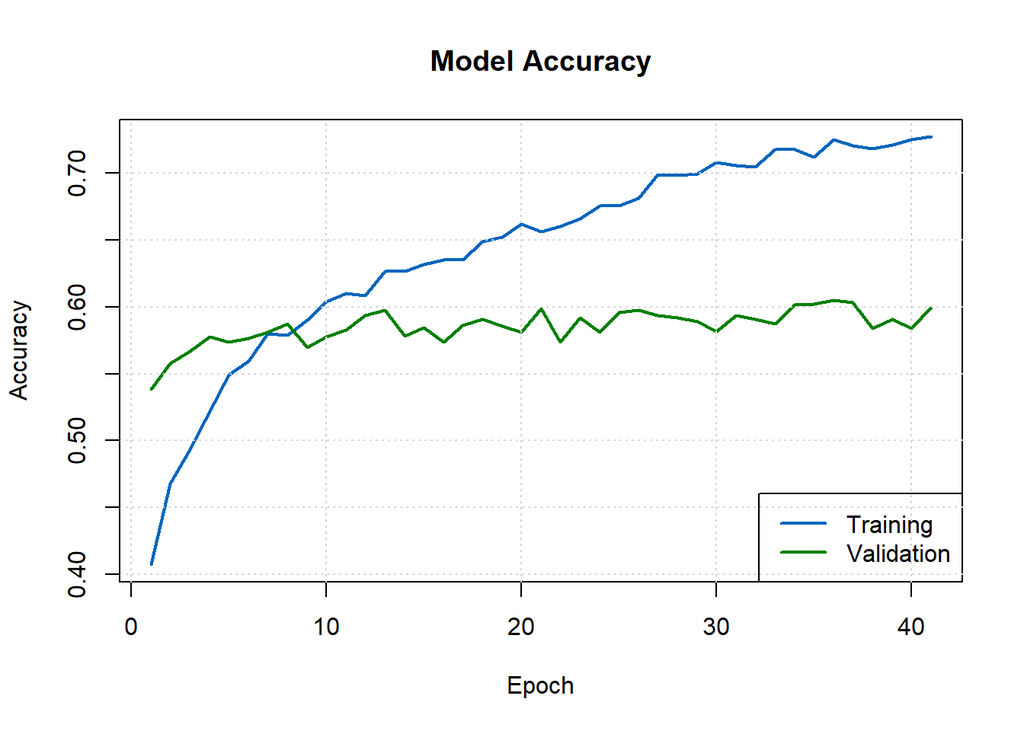

```r
# Add explicit green for validation
validation_green <- "#008000"  # Explicit green for validation elements

# Training history - Accuracy
if(length(final_history$metrics$accuracy) > 0) {
  plot(final_history$metrics$accuracy, type = 'l', col = sais_palette[2],
       main = 'Model Accuracy', ylab = 'Accuracy', xlab = 'Epoch', lwd = 2)
  if(length(final_history$metrics$val_accuracy) > 0) {
    lines(final_history$metrics$val_accuracy, col = validation_green, lwd = 2)
    legend('bottomright', c('Training', 'Validation'), col = c(sais_palette[2], validation_green), lty = 1, lwd = 2)
  }
  grid()
}
```

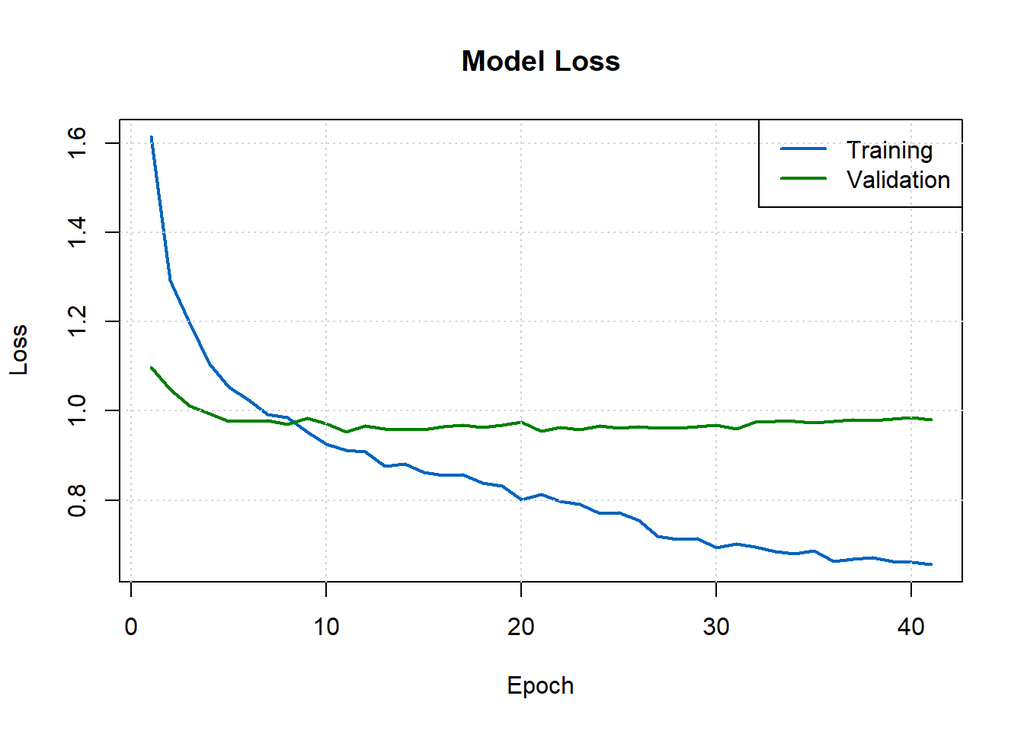

```r
# Training history - Loss (separate plot)
if(length(final_history$metrics$loss) > 0) {
  plot(final_history$metrics$loss, type = 'l', col = sais_palette[2],
       main = 'Model Loss', ylab = 'Loss', xlab = 'Epoch', lwd = 2)
  if(length(final_history$metrics$val_loss) > 0) {
    lines(final_history$metrics$val_loss, col = validation_green, lwd = 2)
    legend('topright', c('Training', 'Validation'), col = c(sais_palette[2], validation_green), lty = 1, lwd = 2)
  }
  grid()
}
```

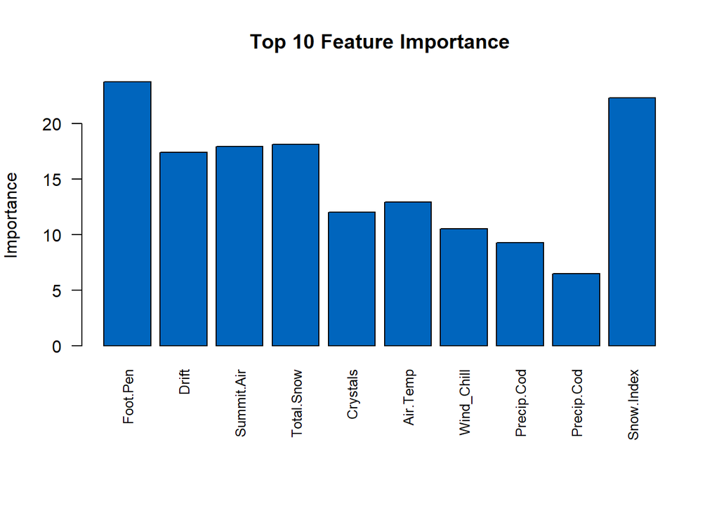

```r
# Feature importance (if Random Forest was successful)
if(exists("rf_importance") && !is.null(rf_importance)) {
  top_features <- head(selected_features, 10)
   par(mar = c(8, 4, 4, 2))  # Larger bottom margin to prevent chopping

  if(length(top_features) > 0 && all(top_features %in% rownames(rf_importance))) {
    barplot(rf_importance[top_features, 1],
            names.arg = substr(top_features, 1, 10),
            las = 2, main = "Top 10 Feature Importance",
            ylab = "Importance", cex.names = 0.8, col = sais_palette[2])
  }
}
```

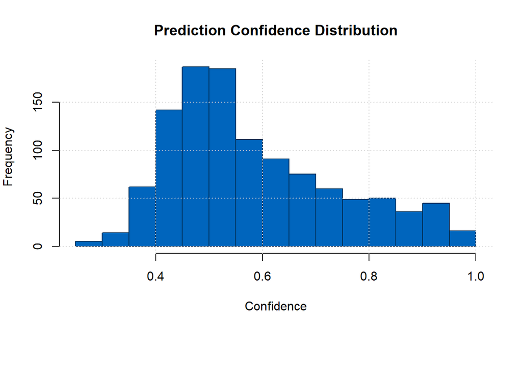

```r
# Prediction confidence histogram (separate plot)
hist(predicted_probs, main = "Prediction Confidence Distribution",
     xlab = "Confidence", ylab = "Frequency", col = sais_palette[2],
     border = sais_palette[1], breaks = 20)
grid()
```

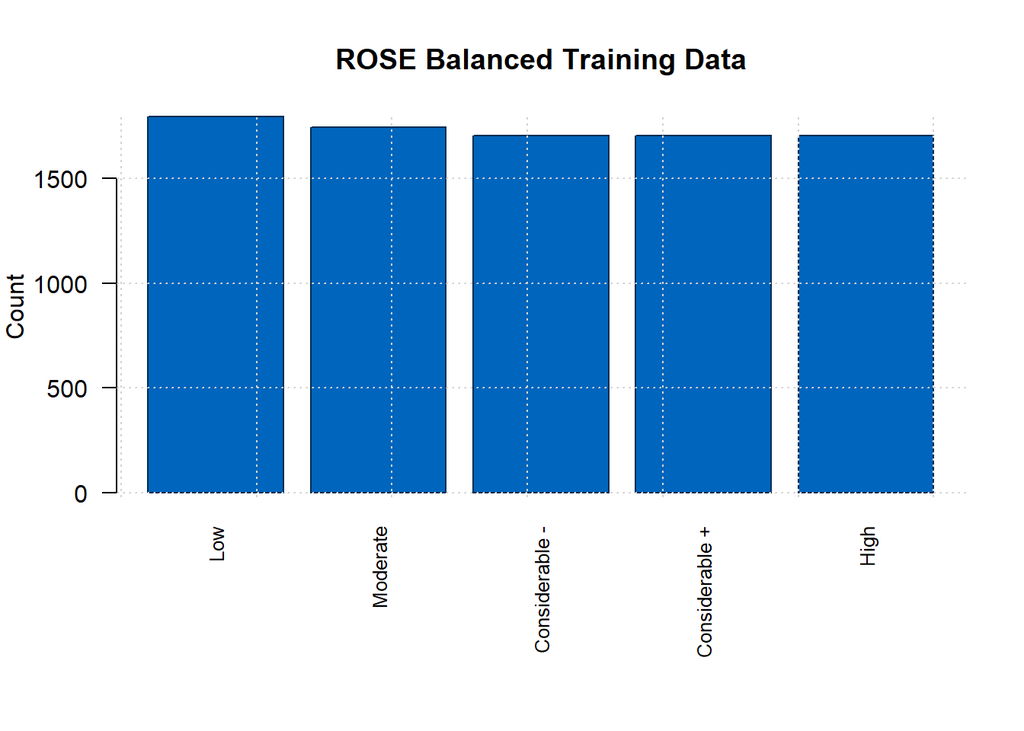

```r
# ROSE Balanced Training Data distribution (separate plot)
# Increase bottom margin for vertical labels
par(mar = c(8, 4, 4, 2))  # Larger bottom margin

barplot(table(balanced_train_data$y), main = "ROSE Balanced Training Data",
        names.arg = fah_levels, ylab = "Count", col = sais_palette[2],  # Use "#0065bd" for bars
        border = sais_palette[1], las = 2, cex.names = 0.8)  # Vertical labels, size 0.8
grid()
```

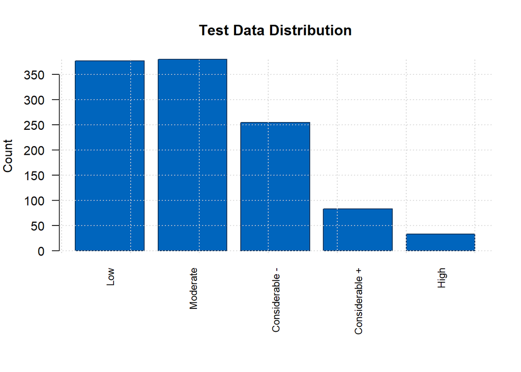

```r
# Reset margins
par(mar = c(5, 4, 4, 2))

# Test Data Distribution (separate plot)
# Increase bottom margin for vertical labels
par(mar = c(8, 4, 4, 2))  # Larger bottom margin

barplot(table(y_test), main = "Test Data Distribution",
        names.arg = fah_levels, ylab = "Count", col = sais_palette[2],  # Use "#0065bd" for bars
        border = sais_palette[1], las = 2, cex.names = 0.8)  # Vertical labels, size 0.8
grid()
```

```r
# Reset margins
par(mar = c(5, 4, 4, 2))

# FINAL INSIGHTS AND RECOMMENDATIONS

cat("\n=== FINAL INSIGHTS AND RECOMMENDATIONS ===\n")
```

```
=== FINAL INSIGHTS AND RECOMMENDATIONS ===
```

```r
cat("Original dataset size:", nrow(final_data), "\n")
```

```
Original dataset size: 7530
```

```r
cat("Training set size after ROSE:", nrow(balanced_train_data), "\n")
```

```
Training set size after ROSE: 8641
```

```r
cat("Number of features selected:", length(selected_features), "\n")
```

```
Number of features selected: 25
```

```r
cat("Best validation accuracy:", sprintf("%.4f", best_score), "\n")
```

```
Best validation accuracy: 0.6129
```

```r
cat("Final test accuracy:", sprintf("%.4f", test_scores$accuracy), "\n")
```

```
Final test accuracy: 0.5851
```

```r
cat("Number of classes:", num_classes, "\n")
```

```
Number of classes: 5
```

```r
# Performance by class analysis
cat("\n=== PERFORMANCE BY AVALANCHE RISK CLASS ===\n")
```

```
=== PERFORMANCE BY AVALANCHE RISK CLASS ===
```

```r
for(i in 0:(num_classes-1)) {
  class_mask <- y_test == i
  if(sum(class_mask) > 0) {
    class_accuracy <- mean(predicted_classes[class_mask] == y_test[class_mask])
    class_count <- sum(class_mask)
    avg_confidence <- mean(predicted_probs[class_mask])
    cat(sprintf("%-15s: Accuracy=%.3f, Count=%3d, Avg Confidence=%.3f\n",
                fah_levels[i+1], class_accuracy, class_count, avg_confidence))
  }
}
```

```
Low            : Accuracy=0.782, Count=377, Avg Confidence=0.692
Moderate       : Accuracy=0.529, Count=380, Avg Confidence=0.547
Considerable - : Accuracy=0.529, Count=255, Avg Confidence=0.502
Considerable + : Accuracy=0.289, Count= 83, Avg Confidence=0.508
High           : Accuracy=0.152, Count= 33, Avg Confidence=0.580
```

```r
# Error analysis
misclassified <- predicted_classes != y_test
if(sum(misclassified) > 0) {
  cat("\n=== ERROR ANALYSIS ===\n")
  cat("Total misclassified predictions:", sum(misclassified), "\n")

  # Low confidence errors
  low_conf_errors <- misclassified & low_confidence
  cat("Low confidence errors:", sum(low_conf_errors), "out of", sum(misclassified), "total errors\n")

  # Most problematic class pairs
  error_df <- data.frame(
    Actual = fah_levels[y_test[misclassified] + 1],
    Predicted = fah_levels[predicted_classes[misclassified] + 1]
  )
  cat("\nMost common misclassification patterns:\n")
  error_patterns <- table(error_df$Actual, error_df$Predicted)
  print(error_patterns)
}
```

```
=== ERROR ANALYSIS ===
Total misclassified predictions: 468
Low confidence errors: 358 out of 468 total errors

Most common misclassification patterns:

                 Considerable - Considerable + High Low Moderate
  Considerable -              0             33    4  11       72
  Considerable +             38              0    2   2       17
  High                       12             14    0   0        2
  Low                        12              2    0   0       68
  Moderate                   69             11    0  99        0
```

```r
# Performance comparison with baseline
baseline_accuracy <- max(table(y_test)) / length(y_test)
improvement <- (test_scores$accuracy - baseline_accuracy) / baseline_accuracy * 100

cat("\n=== PERFORMANCE COMPARISON ===\n")
```

```
=== PERFORMANCE COMPARISON ===
```

```r
cat("Baseline accuracy (most frequent class):", sprintf("%.1f%%", baseline_accuracy * 100), "\n")
```

```
Baseline accuracy (most frequent class): 33.7%
```

```r
cat("Neural network accuracy:", sprintf("%.1f%%", test_scores$accuracy * 100), "\n")
```

```
Neural network accuracy: 58.5%
```

```r
cat("Relative improvement:", sprintf("%.1f%%", improvement), "\n")
```

```
Relative improvement: 73.7%
```

```r
# Feature importance summary
if(exists("feature_scores")) {
  cat("\n=== TOP 10 MOST IMPORTANT FEATURES ===\n")
  top_10_summary <- head(feature_scores, 10)
  for(i in 1:nrow(top_10_summary)) {
    cat(sprintf("%2d. %-25s (Total Score: %.1f)\n",
                i, top_10_summary$Feature[i], top_10_summary$Total_Score[i]))
  }
}
```

```
=== TOP 10 MOST IMPORTANT FEATURES ===
 1. Foot.Pen                  (Total Score: 134.8)
 2. Drift                     (Total Score: 114.6)
 3. Summit.Air.Temp           (Total Score: 106.4)
 4. Total.Snow.Depth          (Total Score: 92.0)
 5. Crystals                  (Total Score: 80.6)
 6. Air.Temp                  (Total Score: 78.6)
 7. Wind_Chill                (Total Score: 65.5)
 8. Precip.Code_X0...None     (Total Score: 65.2)
 9. Precip.Code_X8...Snow     (Total Score: 64.1)
10. Snow.Index                (Total Score: 63.6)
```

```r
# Model architecture summary
cat("\n=== FINAL MODEL ARCHITECTURE SUMMARY ===\n")
```

```
=== FINAL MODEL ARCHITECTURE SUMMARY ===
```

```r
if(exists("best_config")) {
  cat("Architecture: Input ->", best_config$hidden_units_1, "->",
      best_config$hidden_units_2, "->", best_config$hidden_units_3, "-> Output (", num_classes, "classes)\n")
  cat("Regularization: Batch Normalization + Dropout (",
      best_config$dropout_rate_1, ",", best_config$dropout_rate_2, ",",
      best_config$dropout_rate_3, ") + Gaussian Noise\n")
  cat("Optimizer: Adam with learning rate", best_config$learning_rate, "\n")
  cat("Batch size:", best_config$batch_size, "\n")
}
```

```
Architecture: Input -> 512 -> 256 -> 128 -> Output ( 5 classes)
Regularization: Batch Normalization + Dropout ( 0.2 , 0.3 , 0.4 ) + Gaussian Noise
Optimizer: Adam with learning rate 5e-04
Batch size: 32
```

```r
cat("Total parameters: ~", format(final_model$count_params(), big.mark = ","), "\n")
```

```
Total parameters: ~ 181,765
```

```r
cat("Training epochs:", length(final_history$metrics$accuracy), "\n")
```

```
Training epochs: 41
```

```r
# Enhanced TEST SET EVALUATION METRICS

cat("\n=== ENHANCED TEST SET EVALUATION METRICS ===\n")
```

```
=== ENHANCED TEST SET EVALUATION METRICS ===
```

```r
# Calculate comprehensive metrics for multiclass classification
calculate_multiclass_metrics <- function(y_true, y_pred, class_names) {
  # Convert to factors for caret
  y_true_factor <- factor(y_true, levels = 0:(length(class_names)-1), labels = class_names)
  y_pred_factor <- factor(y_pred, levels = 0:(length(class_names)-1), labels = class_names)

  # Overall metrics
  accuracy <- mean(y_true == y_pred)

  # Per-class metrics
  precision_per_class <- c()
  recall_per_class <- c()
  f1_per_class <- c()

  for(i in 0:(length(class_names)-1)) {
    # True positives, false positives, false negatives
    tp <- sum(y_true == i & y_pred == i)
    fp <- sum(y_true != i & y_pred == i)
    fn <- sum(y_true == i & y_pred != i)

    # Calculate metrics
    precision <- ifelse(tp + fp == 0, 0, tp / (tp + fp))
    recall <- ifelse(tp + fn == 0, 0, tp / (tp + fn))
    f1 <- ifelse(precision + recall == 0, 0, 2 * precision * recall / (precision + recall))

    precision_per_class <- c(precision_per_class, precision)
    recall_per_class <- c(recall_per_class, recall)
    f1_per_class <- c(f1_per_class, f1)
  }

  # Macro averages
  macro_precision <- mean(precision_per_class)
  macro_recall <- mean(recall_per_class)
  macro_f1 <- mean(f1_per_class)

  # Weighted averages (weighted by support)
  class_support <- table(y_true)
  weights <- as.numeric(class_support) / sum(class_support)

  weighted_precision <- sum(precision_per_class * weights)
  weighted_recall <- sum(recall_per_class * weights)
  weighted_f1 <- sum(f1_per_class * weights)

  return(list(
    accuracy = accuracy,
    macro_precision = macro_precision,
    macro_recall = macro_recall,
    macro_f1 = macro_f1,
    weighted_precision = weighted_precision,
    weighted_recall = weighted_recall,
    weighted_f1 = weighted_f1,
    per_class_precision = precision_per_class,
    per_class_recall = recall_per_class,
    per_class_f1 = f1_per_class,
    class_names = class_names
  ))
}

# Calculate detailed metrics
detailed_metrics <- calculate_multiclass_metrics(y_test, predicted_classes, fah_levels)

# Display overall metrics
cat("\n=== OVERALL TEST SET METRICS ===\n")
```

```
=== OVERALL TEST SET METRICS ===
```

```r
cat(sprintf("Accuracy:           %.4f\n", detailed_metrics$accuracy))
```

```
Accuracy:           0.5851
```

```r
cat(sprintf("Macro Precision:    %.4f\n", detailed_metrics$macro_precision))
```

```
Macro Precision:    0.5062
```

```r
cat(sprintf("Macro Recall:       %.4f\n", detailed_metrics$macro_recall))
```

```
Macro Recall:       0.4563
```

```r
cat(sprintf("Macro F1-Score:     %.4f\n", detailed_metrics$macro_f1))
```

```
Macro F1-Score:     0.4657
```

```r
cat(sprintf("Weighted Precision: %.4f\n", detailed_metrics$weighted_precision))
```

```
Weighted Precision: 0.5794
```

```r
cat(sprintf("Weighted Recall:    %.4f\n", detailed_metrics$weighted_recall))
```

```
Weighted Recall:    0.5851
```

```r
cat(sprintf("Weighted F1-Score:  %.4f\n", detailed_metrics$weighted_f1))
```

```
Weighted F1-Score:  0.5795
```

```r
# Display per-class metrics
cat("\n=== PER-CLASS METRICS ===\n")
```

```
=== PER-CLASS METRICS ===
```

```r
cat(sprintf("%-15s %9s %9s %9s %9s\n", "Class", "Precision", "Recall", "F1-Score", "Support"))
```

```
Class           Precision    Recall  F1-Score   Support
```

```r
cat(paste(rep("-", 60), collapse = ""), "\n")
class_support <- table(y_test)
for(i in 1:length(fah_levels)) {
  class_name <- fah_levels[i]
  precision <- detailed_metrics$per_class_precision[i]
  recall <- detailed_metrics$per_class_recall[i]
  f1 <- detailed_metrics$per_class_f1[i]
  support <- class_support[as.character(i-1)]

  cat(sprintf("%-15s %9.4f %9.4f %9.4f %9d\n",
              class_name, precision, recall, f1, support))
}
```

```
Low                0.7248    0.7825    0.7526       377
Moderate           0.5583    0.5289    0.5432       380
Considerable -     0.5075    0.5294    0.5182       255
Considerable +     0.2857    0.2892    0.2874        83
High               0.4545    0.1515    0.2273        33
```

```r
# Additional advanced metrics
cat("\n=== ADDITIONAL METRICS ===\n")
```

```
=== ADDITIONAL METRICS ===
```

```r
# Cohen's Kappa (agreement accounting for chance)
tryCatch({
  kappa_result <- kappa2(data.frame(y_test, predicted_classes))
  kappa_score <- kappa_result$value
  cat(sprintf("Cohen's Kappa:      %.4f\n", kappa_score))
}, error = function(e) {
  # Manual Cohen's Kappa calculation if irr package fails
  observed_agreement <- mean(y_test == predicted_classes)

  # Calculate expected agreement by chance
  marginal_actual <- table(y_test) / length(y_test)
  marginal_predicted <- table(predicted_classes) / length(predicted_classes)

  expected_agreement <- 0
  for(i in 0:(length(fah_levels)-1)) {
    if(as.character(i) %in% names(marginal_actual) && as.character(i) %in% names(marginal_predicted)) {
      expected_agreement <- expected_agreement + marginal_actual[as.character(i)] * marginal_predicted[as.character(i)]
    }
  }

  kappa_score <- (observed_agreement - expected_agreement) / (1 - expected_agreement)
  cat(sprintf("Cohen's Kappa:      %.4f (manual calculation)\n", kappa_score))
})
```

```
Cohen's Kappa:      0.4180
```

```r
# Mean Absolute Error for ordinal nature
mae_score <- mean(abs(y_test - predicted_classes))
cat(sprintf("Mean Absolute Error (ordinal): %.4f\n", mae_score))
```

```
Mean Absolute Error (ordinal): 0.4849
```

```r
# Classification error by distance
error_distances <- abs(y_test - predicted_classes)[y_test != predicted_classes]
if(length(error_distances) > 0) {
  cat("\n=== ERROR DISTANCE ANALYSIS ===\n")
  cat("Distribution of prediction errors by distance:\n")
  error_dist_table <- table(error_distances)
  for(dist in names(error_dist_table)) {
    cat(sprintf("Distance %s: %d errors (%.1f%% of total errors)\n",
                dist, error_dist_table[dist],
                error_dist_table[dist]/length(error_distances)*100))
  }
}
```

```
=== ERROR DISTANCE ANALYSIS ===
Distribution of prediction errors by distance:
Distance 1: 395 errors (84.4% of total errors)
Distance 2: 67 errors (14.3% of total errors)
Distance 3: 6 errors (1.3% of total errors)
```

```r
# ORDINAL EVALUATION METRICS

cat("\n=== COMPREHENSIVE ORDINAL EVALUATION METRICS ===\n")
```

```
=== COMPREHENSIVE ORDINAL EVALUATION METRICS ===
```

```r
# Load required library for ordinal metrics
if(!require("Metrics", quietly = TRUE)) {
  install.packages("Metrics")
  library(Metrics)
}

# 1. Mean Absolute Error (MAE) - already calculated above but expanding
cat(sprintf("Mean Absolute Error (MAE):        %.4f\n", mae_score))
```

```
Mean Absolute Error (MAE):        0.4849
```

```r
# 2. Root Mean Squared Error (RMSE) for ordinal data
rmse_score <- sqrt(mean((y_test - predicted_classes)^2))
cat(sprintf("Root Mean Squared Error (RMSE):   %.4f\n", rmse_score))
```

```
Root Mean Squared Error (RMSE):   0.7973
```

```r
# 3. Mean Squared Error (MSE)
mse_score <- mean((y_test - predicted_classes)^2)
cat(sprintf("Mean Squared Error (MSE):         %.4f\n", mse_score))
```

```
Mean Squared Error (MSE):         0.6356
```

```r
# 4. Ordinal classification accuracy (exact match)
ordinal_accuracy <- mean(y_test == predicted_classes)
cat(sprintf("Ordinal Accuracy (exact match):   %.4f\n", ordinal_accuracy))
```

```
Ordinal Accuracy (exact match):   0.5851
```

```r
# 5. Adjacent accuracy (off by at most 1 level)
adjacent_accuracy <- mean(abs(y_test - predicted_classes) <= 1)
cat(sprintf("Adjacent Accuracy (≤1 level off): %.4f\n", adjacent_accuracy))
```

```
Adjacent Accuracy (≤1 level off): 0.9353
```

```r
# 6. Within-2 accuracy (off by at most 2 levels)
within2_accuracy <- mean(abs(y_test - predicted_classes) <= 2)
cat(sprintf("Within-2 Accuracy (≤2 levels off): %.4f\n", within2_accuracy))
```

```
Within-2 Accuracy (≤2 levels off): 0.9947
```

```r
# 7. Ordinal loss (penalizes larger deviations more)
ordinal_loss <- sum(abs(y_test - predicted_classes)^2) / length(y_test)
cat(sprintf("Ordinal Loss (squared deviations): %.4f\n", ordinal_loss))
```

```
Ordinal Loss (squared deviations): 0.6356
```

```r
# 8. Weighted accuracy by distance
distance_weights <- 1 / (1 + abs(y_test - predicted_classes))
weighted_accuracy <- mean(distance_weights)
cat(sprintf("Distance-Weighted Accuracy:       %.4f\n", weighted_accuracy))
```

```
Distance-Weighted Accuracy:       0.7813
```

```r
# 9. Kendall's Tau (rank correlation)
if(require("Kendall", quietly = TRUE)) {
  tryCatch({
    kendall_result <- Kendall(y_test, predicted_classes)
    kendall_tau <- kendall_result$tau
    kendall_p <- kendall_result$sl[1]
    cat(sprintf("Kendall's Tau (rank correlation): %.4f (p-value: %.4f)\n", kendall_tau, kendall_p))
  }, error = function(e) {
    cat("Kendall's Tau calculation failed\n")
  })
} else {
  # Manual calculation of Kendall's Tau
  n <- length(y_test)
  concordant <- 0
  discordant <- 0

  for(i in 1:(n-1)) {
    for(j in (i+1):n) {
      if((y_test[i] - y_test[j]) * (predicted_classes[i] - predicted_classes[j]) > 0) {
        concordant <- concordant + 1
      } else if((y_test[i] - y_test[j]) * (predicted_classes[i] - predicted_classes[j]) < 0) {
        discordant <- discordant + 1
      }
    }
  }

  kendall_tau_manual <- (concordant - discordant) / (n * (n - 1) / 2)
  cat(sprintf("Kendall's Tau (manual calc):      %.4f\n", kendall_tau_manual))
}
```

```
Kendall's Tau (rank correlation): 0.6424 (p-value: 0.0000)
```

```r
# 10. Spearman's rank correlation
spearman_corr <- cor(y_test, predicted_classes, method = "spearman")
cat(sprintf("Spearman's Rank Correlation:      %.4f\n", spearman_corr))
```

```
Spearman's Rank Correlation:      0.7139
```

```r
# 11. Pearson correlation (treating as continuous)
pearson_corr <- cor(y_test, predicted_classes, method = "pearson")
cat(sprintf("Pearson Correlation:              %.4f\n", pearson_corr))
```

```
Pearson Correlation:              0.6984
```

```r
# 12. Cumulative accuracy metrics
cumulative_accuracies <- c()
for(tolerance in 0:4) {
  cum_acc <- mean(abs(y_test - predicted_classes) <= tolerance)
  cumulative_accuracies <- c(cumulative_accuracies, cum_acc)
  cat(sprintf("Cumulative Accuracy (≤%d levels): %.4f\n", tolerance, cum_acc))
}
```

```
Cumulative Accuracy (≤0 levels): 0.5851
Cumulative Accuracy (≤1 levels): 0.9353
Cumulative Accuracy (≤2 levels): 0.9947
Cumulative Accuracy (≤3 levels): 1.0000
Cumulative Accuracy (≤4 levels): 1.0000
```

```r
# 13. Ordinal-specific confusion matrix analysis
cat("\n=== ORDINAL CONFUSION MATRIX ANALYSIS ===\n")
```

```
=== ORDINAL CONFUSION MATRIX ANALYSIS ===
```

```r
# Distance-based confusion analysis
distance_matrix <- outer(0:4, 0:4, function(x, y) abs(x - y))
rownames(distance_matrix) <- fah_levels
colnames(distance_matrix) <- fah_levels

cat("Distance matrix between classes:\n")
```

```
Distance matrix between classes:
```

```r
print(distance_matrix)
```

```
               Low Moderate Considerable - Considerable + High
Low              0        1              2              3    4
Moderate         1        0              1              2    3
Considerable -   2        1              0              1    2
Considerable +   3        2              1              0    1
High             4        3              2              1    0
```

```r
# Weighted confusion matrix (penalizing by distance)
weighted_confusion <- confusion_matrix * distance_matrix[1:nrow(confusion_matrix), 1:ncol(confusion_matrix)]
cat("\nWeighted confusion matrix (errors penalized by distance):\n")
```

```
Weighted confusion matrix (errors penalized by distance):
```

```r
print(weighted_confusion)
```

```
         Actual
Predicted  0  1  2  3  4
        0  0 99 22  6  0
        1 68  0 72 34  6
        2 24 69  0 38 24
        3  6 22 33  0 14
        4  0  0  8  2  0
```

```r
# Total weighted error
total_weighted_error <- sum(weighted_confusion)
cat(sprintf("Total Weighted Error Score: %.2f\n", total_weighted_error))
```

```
Total Weighted Error Score: 547.00
```

```r
# 14. Severity-weighted metrics (higher penalties for severe misclassifications)
severity_weights <- c(1, 2, 4, 8, 16)  # Exponential penalty for higher risk misses
severity_penalty <- 0

for(i in 1:length(y_test)) {
  actual_severity <- severity_weights[y_test[i] + 1]
  predicted_severity <- severity_weights[predicted_classes[i] + 1]

  # Penalty for underestimating risk (more dangerous)
  if(predicted_classes[i] < y_test[i]) {
    severity_penalty <- severity_penalty + (actual_severity - predicted_severity) * 2
  }
  # Penalty for overestimating risk (less dangerous but still costly)
  else if(predicted_classes[i] > y_test[i]) {
    severity_penalty <- severity_penalty + (predicted_severity - actual_severity) * 1
  }
}

avg_severity_penalty <- severity_penalty / length(y_test)
cat(sprintf("Average Severity Penalty:         %.4f\n", avg_severity_penalty))
```

```
Average Severity Penalty:         1.9273
```

```r
# 15. Directional accuracy (proportion of correct trends)
# For ordinal data, we can assess if the model correctly identifies the direction of risk
correct_direction <- 0
total_comparisons <- 0

for(i in 1:(length(y_test)-1)) {
  for(j in (i+1):length(y_test)) {
    actual_diff <- y_test[i] - y_test[j]
    predicted_diff <- predicted_classes[i] - predicted_classes[j]

    if(actual_diff != 0) {  # Only consider cases where there's an actual difference
      if(sign(actual_diff) == sign(predicted_diff)) {
        correct_direction <- correct_direction + 1
      }
      total_comparisons <- total_comparisons + 1
    }
  }
}

directional_accuracy <- ifelse(total_comparisons > 0, correct_direction / total_comparisons, 0)
cat(sprintf("Directional Accuracy:             %.4f\n", directional_accuracy))
```

```
Directional Accuracy:             0.7098
```

```r
# 16. Proportional reduction in error (compared to baseline ordinal prediction)
baseline_mae <- mean(abs(y_test - median(y_test)))
proportional_reduction <- (baseline_mae - mae_score) / baseline_mae
cat(sprintf("Proportional Reduction in MAE:    %.4f\n", proportional_reduction))
```

```
Proportional Reduction in MAE:    0.3902
```

```r
# 17. Ordinal classification summary table
cat("\n=== ORDINAL CLASSIFICATION SUMMARY TABLE ===\n")
```

```
=== ORDINAL CLASSIFICATION SUMMARY TABLE ===
```

```r
ordinal_summary <- data.frame(
  Metric = c("Exact Accuracy", "Adjacent Accuracy (±1)", "Within-2 Accuracy (±2)",
             "MAE", "RMSE", "Kendall's Tau", "Spearman's ρ", "Directional Accuracy"),
  Value = c(ordinal_accuracy, adjacent_accuracy, within2_accuracy,
            mae_score, rmse_score,
            ifelse(exists("kendall_tau"), kendall_tau,
                   ifelse(exists("kendall_tau_manual"), kendall_tau_manual, NA)),
            spearman_corr, directional_accuracy),
  Interpretation = c("Perfect predictions", "Off by ≤1 level", "Off by ≤2 levels",
                    "Avg distance from true", "Penalizes large errors",
                    "Rank correlation", "Rank correlation", "Correct ordering"),
  stringsAsFactors = FALSE
)

kable(ordinal_summary, digits = 4,
           caption = "Comprehensive Ordinal Classification Metrics") %>%
  kable_styling(bootstrap_options = c("striped", "hover", "condensed"))
```

Comprehensive Ordinal Classification Metrics

| Metric | Value | Interpretation |
| --- | --- | --- |
| Exact Accuracy | 0.5851 | Perfect predictions |
| Adjacent Accuracy (±1) | 0.9353 | Off by ≤1 level |
| Within-2 Accuracy (±2) | 0.9947 | Off by ≤2 levels |
| MAE | 0.4849 | Avg distance from true |
| RMSE | 0.7973 | Penalizes large errors |
| Kendall's Tau | 0.6424 | Rank correlation |
| Spearman's ρ | 0.7139 | Rank correlation |
| Directional Accuracy | 0.7098 | Correct ordering |

```r
# 18. Risk assessment specific metrics for avalanche prediction
cat("\n=== AVALANCHE-SPECIFIC RISK ASSESSMENT METRICS ===\n")
```

```
=== AVALANCHE-SPECIFIC RISK ASSESSMENT METRICS ===
```

```r
# Critical miss rate (predicting lower risk when actual is high)
high_risk_actual <- y_test >= 3  # Considerable+ and High
low_predicted_for_high_actual <- (y_test >= 3) & (predicted_classes <= 1)  # Predicted Low/Moderate
critical_miss_rate <- sum(low_predicted_for_high_actual) / sum(high_risk_actual)

cat(sprintf("Critical Miss Rate (Low pred/High actual): %.4f\n", critical_miss_rate))
```

```
Critical Miss Rate (Low pred/High actual): 0.1810
```

```r
# Conservative bias (tendency to over-predict risk)
conservative_predictions <- sum(predicted_classes > y_test)
liberal_predictions <- sum(predicted_classes < y_test)
conservative_bias <- (conservative_predictions - liberal_predictions) / length(y_test)

cat(sprintf("Conservative Bias (>0 = over-predict):    %.4f\n", conservative_bias))
```

```
Conservative Bias (>0 = over-predict):    -0.0585
```

```r
# Safety margin effectiveness
safe_predictions <- sum(predicted_classes >= y_test)  # At or above actual risk
safety_effectiveness <- safe_predictions / length(y_test)

cat(sprintf("Safety Effectiveness (≥actual risk):     %.4f\n", safety_effectiveness))
```

```
Safety Effectiveness (≥actual risk):     0.7633
```

```r
# High-risk detection sensitivity and specificity
high_risk_threshold <- 2  # Considerable- and above
true_high_risk <- y_test >= high_risk_threshold
predicted_high_risk <- predicted_classes >= high_risk_threshold

high_risk_sensitivity <- sum(true_high_risk & predicted_high_risk) / sum(true_high_risk)
high_risk_specificity <- sum(!true_high_risk & !predicted_high_risk) / sum(!true_high_risk)

cat(sprintf("High-Risk Sensitivity (detect high):     %.4f\n", high_risk_sensitivity))
```

```
High-Risk Sensitivity (detect high):     0.7197
```

```r
cat(sprintf("High-Risk Specificity (avoid false+):    %.4f\n", high_risk_specificity))
```

```
High-Risk Specificity (avoid false+):    0.8758
```

```r
# Model confidence analysis for different risk levels
cat("\n=== CONFIDENCE ANALYSIS BY RISK LEVEL ===\n")
```

```
=== CONFIDENCE ANALYSIS BY RISK LEVEL ===
```

```r
for(risk_level in 0:4) {
  if(sum(y_test == risk_level) > 0) {
    level_mask <- y_test == risk_level
    avg_confidence <- mean(predicted_probs[level_mask])
    correct_predictions <- sum(predicted_classes[level_mask] == y_test[level_mask])
    total_predictions <- sum(level_mask)
    accuracy_at_level <- correct_predictions / total_predictions

    cat(sprintf("%-15s: Avg Confidence=%.3f, Accuracy=%.3f, Count=%d\n",
                fah_levels[risk_level + 1], avg_confidence, accuracy_at_level, total_predictions))
  }
}
```

```
Low            : Avg Confidence=0.692, Accuracy=0.782, Count=377
Moderate       : Avg Confidence=0.547, Accuracy=0.529, Count=380
Considerable - : Avg Confidence=0.502, Accuracy=0.529, Count=255
Considerable + : Avg Confidence=0.508, Accuracy=0.289, Count=83
High           : Avg Confidence=0.580, Accuracy=0.152, Count=33
```

```r
# Final ordinal performance summary
cat("\n=== FINAL ORDINAL PERFORMANCE SUMMARY ===\n")
```

```
=== FINAL ORDINAL PERFORMANCE SUMMARY ===
```

```r
cat("==========================================\n")
cat(sprintf("Model Performance on Ordinal Avalanche Risk Prediction:\n"))
```

```
Model Performance on Ordinal Avalanche Risk Prediction:
```

```r
cat(sprintf("- Exact Match Accuracy:     %.1f%%\n", ordinal_accuracy * 100))
```

```
- Exact Match Accuracy:     58.5%
```

```r
cat(sprintf("- Adjacent Accuracy (±1):   %.1f%%\n", adjacent_accuracy * 100))
```

```
- Adjacent Accuracy (±1):   93.5%
```

```r
cat(sprintf("- Safety Effectiveness:     %.1f%%\n", safety_effectiveness * 100))
```

```
- Safety Effectiveness:     76.3%
```

```r
cat(sprintf("- Critical Miss Rate:       %.1f%%\n", critical_miss_rate * 100))
```

```
- Critical Miss Rate:       18.1%
```

```r
cat(sprintf("- Mean Absolute Error:      %.2f levels\n", mae_score))
```

```
- Mean Absolute Error:      0.48 levels
```

```r
cat(sprintf("- Rank Correlation:         %.3f\n", spearman_corr))
```

```
- Rank Correlation:         0.714
```

```r
cat(sprintf("- Conservative Bias:        %.3f\n", conservative_bias))
```

```
- Conservative Bias:        -0.059
```

```r
if(critical_miss_rate < 0.05) {
  cat("✓ Excellent safety performance (critical miss rate < 5%)\n")
} else if(critical_miss_rate < 0.10) {
  cat("⚠ Good safety performance (critical miss rate < 10%)\n")
} else {
  cat("⚠ Concerning safety performance (critical miss rate ≥ 10%)\n")
}
```

```
⚠ Concerning safety performance (critical miss rate ≥ 10%)
```

```r
if(adjacent_accuracy > 0.90) {
  cat("✓ Excellent ordinal accuracy (>90% within ±1 level)\n")
} else if(adjacent_accuracy > 0.80) {
  cat("✓ Good ordinal accuracy (>80% within ±1 level)\n")
} else {
  cat("⚠ Moderate ordinal accuracy (<80% within ±1 level)\n")
}
```

```
✓ Excellent ordinal accuracy (>90% within ±1 level)
```

```r
cat("==========================================\n")
# Clean up
rm(list = ls()[grepl("temp|tmp", ls())])
gc()
```

```
          used  (Mb) gc trigger  (Mb) max used  (Mb)
Ncells 2998502 160.2    5153475 275.3  5153475 275.3
Vcells 9966801  76.1   24005158 183.2 24001389 183.2
```

```r
cat("\n=== MODEL TRAINING AND EVALUATION COMPLETE ===\n")
```

```
=== MODEL TRAINING AND EVALUATION COMPLETE ===
```